# Reproduction of Baker’s paper in Nature

František Kalvas, Petr Jedlička

02. 10. 2026

# Poznámky

##Návod na přidání nové proměnné do analýzy

- Ve snipetu *Loading Jedlička* přidat do *select* nebo do *mutate*
- Ve snipetu “Loading Baker” přidat čésůp číslo sloupceš (číslo sloupce v Excelu + 1) a o řádek níž upravit první argument funnkce *prejemnuj* a v druhám přídat název sloupce.

# Úvod a příprava dat

Reprodukujeme následující článek a grafy v něm: (https://www.nature.com/articles/533452a)[https://www.nature.com/articles/533452a]

## Načtení dat

Data byla pipravená pomocí skriptu `preprocess.Rmd`, z něj si lze vybrat dva soubory, jeden by měl být hůře připravený, ale s úplně všemi proměnnými, na které jsme se ptali (`dataAll.RData`) a druhý by měl být selektovaný, ale lépe připravený (`dataProcessed.RData`). Zkusím je nedřív porovnat.

```r
load("dataAll.RData")
complete = data

# MŠ (2026-10-02): dataProcessed.RData se už nevytváří (viz preprocess.Rmd); srovnání jen pokud soubor existuje.
if (file.exists("dataProcessed.RData")) {
  load("dataProcessed.RData")
  selected = data

  print(ncol(complete) == ncol(selected))
  print(ncol(complete)); print(ncol(selected))
}
```

## Hledání proměnných pro komparaci s Baker in Nature

```r
tibble(
  `Baker Graph` = c("Is there reproducibility crisis?",
            "HOW MUCH PUBLISHED WORK IN YOUR FIELD IS REPRODUCIBLE?",
            "Obory (Chemistry, Phycs & Engineering, Earth & Environment, Biology, Medicine, Other)",
            "HAVE YOU FAILED TO REPRODUCE AN EXPERIMENT? (Own/Someone's else)",
            "WHAT FACTORS CONTRIBUTE TO IRREPRODUCIBLE RESEARCH?",
            "HAVE YOU EVER TRIED TO PUBLISH A REPRODUCTION ATTEMPT? (Successful/Unsuccessful)",
            "HAVE YOU ESTABLISHED PROCEDURES FOR REPRODUCIBILITY?",
            "---",
            "---"),
  `Baker Var` = c("(20) Which of the following statement regarding a 'crisis or reproducibility' within the science community do you agree with?",
               "(22) In your opinion, what proportion of published results in your field are reproducible? i.e. the results of a given study could be replicated exactly or reproduced in multiple similar experimental systems with variations of experimental settings such as materials and experimental model)",
               "(91) Which of the following best describes your area of interest?",
               "(79) Which, if any, of the following have you done?, (80) ...80",
               "(52--65) Please use the scale below to indicate how much each of the following factors contributes to a failure to reproduce results:, ...53 -- ...65",
               "(81--84) ...81, ...82, ...83, ...84 ",
               "(40) Have you and/or your lab group established any procedures to ensure reproducibility in your work?, (42) When did you and/or your lab group establish these procedures?",
               "(85) Has anyone ever told you that they could not reproduce results from one of your own experiments?",
               "(109) In which continent do you live?, (110--115) Which country in ..."),
  `My Var: complete` = c("krize_rep",
               "rep_podil",
               "spec_hlavni",
               "nerep_jaMuj, nerep_jaCizi",
               "fakt_podvod -- fakt_smula",
               "---",
               "---",
               "nerep_oniMuj",
               "---"),
  `My Var: selected` = c("krize_rep",
               "---",
               "spec_hlavni",
               "---",
               "---",
               "---",
               "---",
               "---",
               "---")
) %>% kable()
```

| Baker Graph | Baker Var | My Var: complete | My Var: selected |
| --- | --- | --- | --- |
| Is there reproducibility crisis? | (20) Which of the following statement regarding a ‘crisis or reproducibility’ within the science community do you agree with? | krize_rep | krize_rep |
| HOW MUCH PUBLISHED WORK IN YOUR FIELD IS REPRODUCIBLE? | (22) In your opinion, what proportion of published results in your field are reproducible? i.e. the results of a given study could be replicated exactly or reproduced in multiple similar experimental … | rep_podil | — |
| Obory (Chemistry, Phycs & Engineering, Earth & Environment, Biology, Medicine, Other) | (91) Which of the following best describes your area of interest? | spec_hlavni | spec_hlavni |
| HAVE YOU FAILED TO REPRODUCE AN EXPERIMENT? (Own/Someone’s else) | (79) Which, if any, of the following have you done?, (80) …80 | nerep_jaMuj, nerep_jaCizi | — |
| WHAT FACTORS CONTRIBUTE TO IRREPRODUCIBLE RESEARCH? | (52–65) Please use the scale below to indicate how much each of the following factors contributes to a failure to reproduce results:, …53 – …65 | fakt_podvod – fakt_smula | — |
| HAVE YOU EVER TRIED TO PUBLISH A REPRODUCTION ATTEMPT? (Successful/Unsuccessful) | (81–84) …81, …82, …83, …84 | — | — |
| HAVE YOU ESTABLISHED PROCEDURES FOR REPRODUCIBILITY? | (40) Have you and/or your lab group established any procedures to ensure reproducibility in your work?, (42) When did you and/or your lab group establish these procedures? | — | — |
| — | (85) Has anyone ever told you that they could not reproduce results from one of your own experiments? | nerep_oniMuj | — |
| — | (109) In which continent do you live?, (110–115) Which country in … | — | — |

## Příprava a spojování dat

Teď jsme si udělali jasno ohledně možné komparace dat z obou výzkumů. Je jasné, že je třeba vzít `dataAll.RData`, neboť v těch selektovaných datech nic pořádně na srovnání s Baker není. Teď si tedy podle tabulky výše upravím objekt `complete` a z něj vyberu vše, co je komparovatelné.

```r
my = filter(complete, cas_sec >= 600, zakl_vyzkum == "Ano") %>%
  select(krize_rep, rep_podil, spec_hlavni, nerep_jaMuj, nerep_oniMuj,
         nerep_jaCizi, fakt_podvod:fakt_smula,
         starts_with("reg_"), starts_with("nerep_"),  starts_with("desp"),  starts_with("reakce_"),
         frek_nerepre:neobj_salam, gender:kar_kategorie) %>%
  mutate(
    Author = "Jedlička",
    continent = "Europe",
    Country = "Czech Republic",
    across(
      c(krize_rep, spec_hlavni:fakt_smula, despekt, nerep_problem:nerep_narust),
      ~recode(
        .x,
        Nevím = "I don't know", Ano = "Yes", Ne = "No", `Nepamatuji se` = "I can't remember" ,
        `Nedělám experimenty` = "I don't do experiments",
        `Ano, významná krize` = "Yes, significant crisis",
        `Ano, nevýznamná krize` = "Yes, slight crisis",
        `Ne, žádná krize není` = "No crisis",
        # `Astronomy and planetary science` = "Astronomy and Planetary Science",
        `Mathematics` = "Other specialization",
        Vždy = "Always", Nikdy = "Never",
        Zřídka = "Rarely", Někdy = "Sometimes",
        `Velmi často` = "Very often",
        `Rozhodně souhlasím` = "Strongly agree", `Spíše souhlasím` = "Agree",
        `Ani souhlasím/ani nesouhlasím` = "Neither agree nor disagree",
        `Spíše nesouhlasím` = "Disagree", `Rozhodně nesouhlasím` = "Strongly disagree"
      )
    ),
    across(
      starts_with("neobj_"),
      ~recode(.x, Ano = "100", Ne = "0") %>% parse_number()
    ),
    across(
      starts_with("frek_"),
      ~parse_number(.x)
    )
  )
```

```
## Warning: There were 16 warnings in `mutate()`.
## The first warning was:
## ℹ In argument: `across(...)`.
## Caused by warning:
## ! 71 parsing failures.
## row col expected actual
##  60  -- a number  Nevím
##  62  -- a number  Nevím
##  84  -- a number  Nevím
## 119  -- a number  Nevím
## 127  -- a number  Nevím
## ... ... ........ ......
## See problems(...) for more details.
## ℹ Run `dplyr::last_dplyr_warnings()` to see the 15 remaining warnings.
```

MŠ: Warningy, které hlásí, se týkají případů, kdy v proměnných freq_xxx ne vyplněno Nevím, které překoduje do NA.

Aha… Tak když jsme dali limit 10 minut, tak jsme přišli o 20 lidí, vzorek klesne na 1001, když to dáme na 12 minut, tak to klesne až na 967, to je dalších 33 lidí, tedy přijdeme o 53 lidí, tedy 5% vzorku… No, já to teď nechám na těch 12 minutách, ale stačí říct, že by se těch dalších 33 lidí hodilo a já to celé sjedu s limitem 600 sekund. Ápropós, když limit snížím na 15 minut, tak vzorem klesne až na 878 respondentů.

```r
tibble(`Časový limit (minuty)` = c(0, 10, 12, 15), N = c(1021, 1001, 967, 878)) %>% kable()
```

| Časový limit (minuty) | N |
| --- | --- |
| 0 | 1021 |
| 10 | 1001 |
| 12 | 967 |
| 15 | 878 |

Teď musíme provést totéž s daty od Baker. Načteme je, vybereme z nich proměnné a nakonec je budeme rekódovat tak, aby data byla srovnatelná.

MŠ: přidal jsem Country, která slučuje cntr.x

```r
# Definice vlastní funkce pro lepší pejmenování
prejmenuj = function(tdf, pozice, jmena) {
  if (length(jmena) < 1) stop(print('Musíte zadat nějaká jména!'))
  if (length(pozice) < 1) stop(print('Musíte zadat nějaké pozice!'))
  if (length(pozice) !=  length(jmena)) stop(print('délka vektoru nových jmen a délka vektoru pozic se musí shodovat!'))
  for (i in 1:length(jmena)) {
    names(tdf)[pozice[i]] = jmena[i]
  }
  tdf
}


Baker = read_xlsx("../data_and_R_src/dataNature.xlsx", skip = 1) %>%
  select(c(20, 22, 91, 79:80, 52:65, 85, 89, 24, 25, 50, 51, 109:115)) %>%
  prejmenuj(1:32,
            c("krize_rep", "rep_podil", "spec_hlavni", "nerep_jaMuj", "nerep_jaCizi",
              'fakt_podvod', 'fakt_karier', 'fakt_dohled', 'fakt_recenz', 'fakt_selekc',
              'fakt_replik', 'fakt_statis', 'fakt_odborn', 'fakt_data', 'fakt_dokume',
              'fakt_metody', 'fakt_variab', 'fakt_design', 'fakt_smula',
              "nerep_oniMuj", "educ",
              "nerep_problem", "nerep_problemAll", "nerep_chyba", "nerep_valid",
              # MŠ (2026-10-02): Baker sl. 51 ("failure to reproduce rarely detracts from the validity
              #   of the original finding") odpovídá české otázce 9 "...jen málokdy ubírá na validitě
              #   originálního zjištění" = nerep_valid. Dříve chybně mapováno na nerep_neobj
              #   ("Nereprodukovatelné výsledky ubírají vědě na objektivitě"), což je jiný výrok.
               "continent", "cntr.1", "cntr.2", "cntr.3", "cntr.4", "cntr.5", "cntr.6"
              )) %>%
  mutate(
      across(
      c(krize_rep:nerep_oniMuj),
      ~recode(
        .x,
        # `I don't know` = `Nevím`, Yes = "Ano", No = "Ne", `I can't remember` = "Nepamatuji se",
        `There is a significant crisis of reproducibility` = "Yes, significant crisis",
        `There is a slight crisis of reproducibility` = "Yes, slight crisis",
        `There is no crisis of reproducibility` = "No crisis",
        `Astronomy and planetary science` = "Astronomy and Planetary Science",
        `Other` = "Other specialization",
        `Always contributes` = "Always", `Never contributes` = "Never",
        `Rarely contributes` = "Rarely", `Sometimes contributes` = "Sometimes",
        `Very often contributes` = "Very often"
      )
    )
  )
  Baker <- Baker %>%
    rowwise() %>%
     mutate( Author = "Baker",
       Country = paste0(na.omit(c_across(starts_with("cntr."))), collapse = ", ")
 )
```

Tak proměnné jsou vybrané a základní příprava hotová, teď můžeme soubory spojit, aby je bylo možné porovnat, dočištění, které lze udělat společně, to uděláme společně teď, tedy hned po spojení:

```r
df = add_rows(my, Baker) %>%  # Takto spojíme soubory
  mutate(
    rep_podil = parse_number(rep_podil),
    across(
      c(krize_rep, spec_hlavni:fakt_smula, despekt, Author),
      ~factor(
        .x,
        levels =
          c("Yes, significant crisis", "Yes, slight crisis", "No crisis", "Yes", "No",
            "I can't remember", "I don't do experiments", "Astronomy and Planetary Science", "Biology", "Chemistry",
            "Earth and Environmental Science", "Engineering", "Materials Science",  # "Mathematics",
            "Medicine", "Physics", "Other specialization", "Baker", "Jedlička",
            "Always", "Very often", "Sometimes", "Rarely", "Never", "Strongly agree", "Agree",
            "Neither agree nor disagree", "Disagree", "Strongly disagree", "I don't know"
            )
        )
     )
  )
```

```
## Warning: There was 1 warning in `mutate()`.
## ℹ In argument: `rep_podil = parse_number(rep_podil)`.
## Caused by warning:
## ! 82 parsing failures.
## row col expected actual
##  46  -- a number  Nevím
##  49  -- a number  Nevím
##  59  -- a number  Nevím
##  79  -- a number  Nevím
##  85  -- a number  Nevím
## ... ... ........ ......
## See problems(...) for more details.
```

MŠ: Warningy viz výše

# Grafy

V téhle části jednak zreplikuju grafy Monyi Baker z Nature a rovnou je srovnám s našimi výsledky. Grafy vezmu popořadě.

## Is there reproducibility crisis?

[figure not shown]

Jinak, překvapení se nekoná, graf z Nature sedí, čísla jsme reprodukovali.

```r
dfspecs <- df %>%
  select(krize_rep, Author, spec_hlavni) %>%
  filter(!is.na(krize_rep)) %>%
  group_by(Author, spec_hlavni) %>%
  summarize(N = n())
```

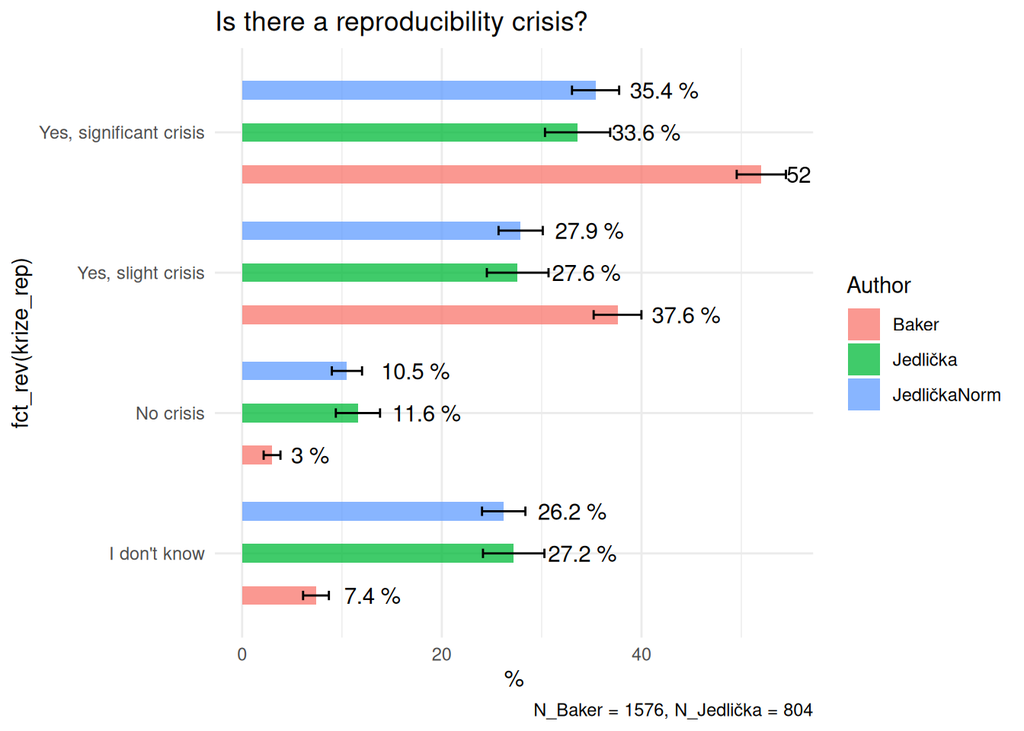

```r
dfjedlicka <- dfspecs  %>%
    filter(Author == "Jedlička")

dfbaker <- dfspecs  %>%
    filter(Author == "Baker") %>%
  rename(
    Baker_N = N
  )

dfw <- dfjedlicka  %>%
  left_join(dfbaker, by="spec_hlavni") %>%
  mutate( w = Baker_N / N)

dfraw <- df %>%
#  filter(krize_rep != "I don't know") %>%
  select(krize_rep, Author) %>%
  filter(!is.na(krize_rep)) %>%
  group_by(Author) %>%
  mutate(N = n())  %>%
  group_by(Author, krize_rep, N) %>%
  summarise(n = n(), .groups = "drop")

dfadj <- df  %>%
#  filter(krize_rep != "I don't know") %>%
  filter(!is.na(krize_rep)) %>%
  select(krize_rep, Author,spec_hlavni) %>%
  filter(Author == "Jedlička") %>%
  mutate(Author = "JedličkaNorm") %>%
  left_join(dfw, by="spec_hlavni") %>%
  select(krize_rep, Author, w) %>%
  group_by(Author) %>%
  mutate(N = sum(w))  %>%
  group_by(Author, krize_rep, N) %>%
  summarise(n = sum(w), .groups = "drop")

df_total <- bind_rows(dfraw,dfadj)

df_total <- df_total %>%
  mutate(f = round(n / N * 100, 1)) %>%
  mutate(se = sqrt((f * (100 - f)) / N),  # Standard error
         lower = f - 1.96 * se,           # 95% CI Lower Bound
         upper = f + 1.96 * se)           # 95% CI Upper Bound

dodge_width <- 0.9  # Adjust dodging width for correct spacing

ggplot(df_total, aes(y = fct_rev(krize_rep), x = f, fill = Author, label = paste(f, "%"))) +
  geom_col(alpha = 0.75, na.rm = TRUE, position = position_dodge(width = dodge_width),
           width = 0.4) +  # Reduce bar width to avoid overlap
  geom_errorbar(aes(xmin = lower, xmax = upper),
                width = 0.2,
                position = position_dodge(width = dodge_width)) +
  geom_text(position = position_dodge(width = dodge_width), hjust = -0.5) +
  labs(title = "Is there a reproducibility crisis?", x = "%",
       caption = paste0("N_Baker = ", df_total[1, "N"],
                        ", N_Jedlička = ", df_total[8, "N"])) +
  theme_minimal()
```

A když uděláme exaktní statistickej test toho, že mezi těmi, co vědí, jsou poměry stejné u nás a u bakerové, vyjde supersignifikantně (že ne).

Pořadí obdélníčků je v kr_levels.

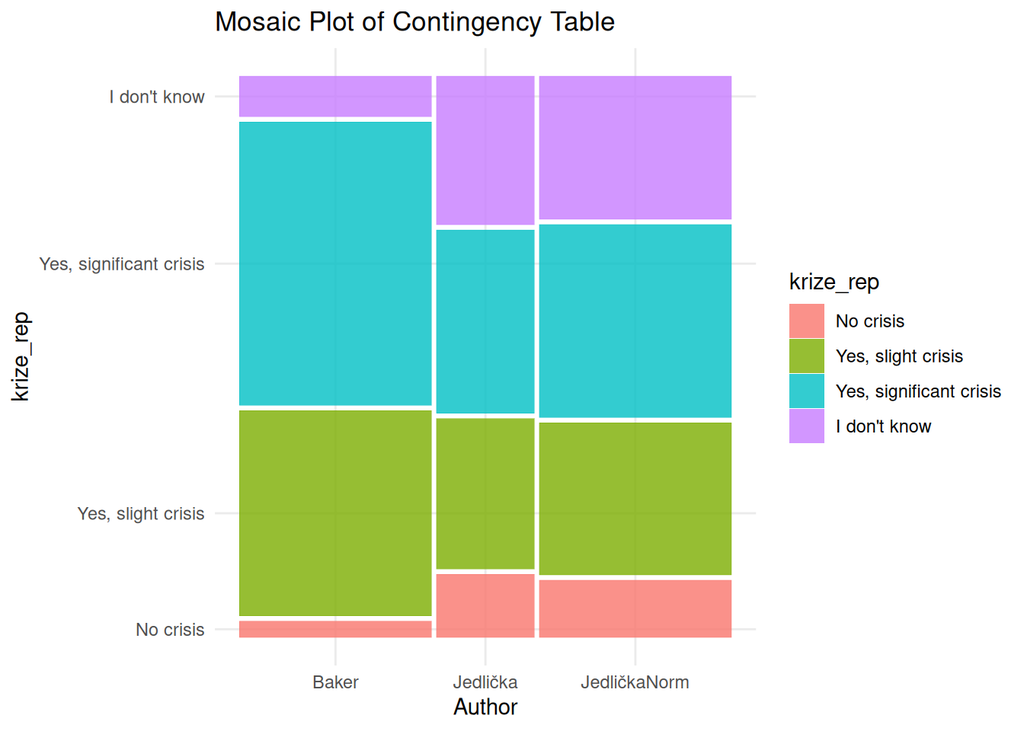

```r
# Ensure the dataframe is ungrouped

kr_levels <- c("No crisis", "Yes, slight crisis",
    "Yes, significant crisis", "I don't know" )

reduced_dfs <- df_total %>%
  select(Author, krize_rep, n) %>%
  ungroup() %>%
  mutate(
    krize_rep = factor(krize_rep, levels = kr_levels),
    Author = as.character(Author)
  )


# Convert to contingency table
data_for_chisq <- xtabs(n ~ Author + krize_rep, data = reduced_dfs)

# Perform Chi-Square Test
chi_result <- chisq.test(data_for_chisq)

data_df <- as.data.frame(as.table(data_for_chisq))

# Ensure krize_rep ordering is kept
data_df$krize_rep <- factor(data_df$krize_rep, levels = levels(reduced_dfs$krize_rep))

# Mosaic plot with your custom ordering for stacked values (krize_rep)
ggplot(data_df) +
  geom_mosaic(aes(weight = Freq, x = product(Author), fill = krize_rep)) +
  labs(title = "Mosaic Plot of Contingency Table",
       x = "Author",
       y = "krize_rep",
       fill = "krize_rep") +
  theme_minimal()
```

```r
# Print results
print(chi_result)
```

```
##
##  Pearson's Chi-squared test
##
## data:  data_for_chisq
## X-squared = 357.4, df = 6, p-value < 2.2e-16
```

Takže hypotéza *Náhodně vybraný vědecký týpek to má tak a tak* v Česku neplatí. Tak ted zkoumejme, zda to vyjde aspoň po zohlednění kontinentu, a rozdělíme Evropu na východní a západní. Klasifikace zemí je uložena v níže uvedeném souboru (Baker rozlišuje jen jednu Evropu).

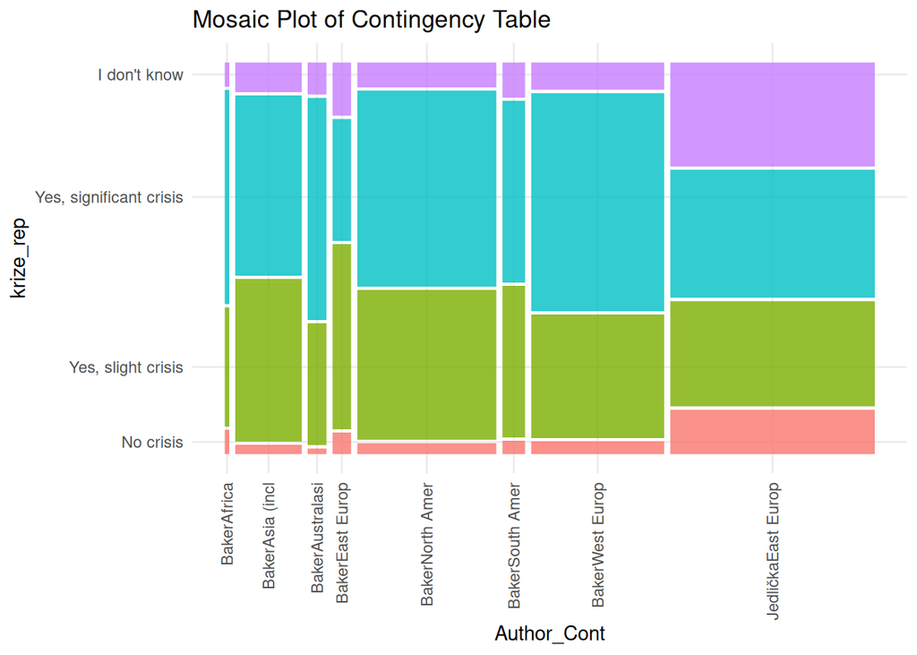

```r
# Read the CSV file containing East and West Europe classification
europe_regions <- read.csv("east_and_west_europe.csv")

# Assume `df` is your main data frame with a "Continent" column
# Merge with `df` based on country
df <- df %>%
  left_join(europe_regions, by = "Country") %>%  # Adjust "Country" if needed
  mutate(Subcontinent = ifelse(continent == "Europe", Region, continent)) %>%
  select(-Region)  # Remove the Region column if no longer needed

# Print updated data frame


dfsknowingcontinent <- df %>%
#  filter(krize_rep != "I don't know") %>%
  select(krize_rep, Author, Subcontinent) %>%
  filter(!is.na(krize_rep)) %>%
  group_by(Author, Subcontinent) %>%
  mutate(N = n()) %>%
  group_by(Author, Subcontinent, krize_rep, N) %>%
  summarise(n = n(), .groups = "drop") %>%
  mutate(f = round(n / N * 100, 1)) %>%
  mutate(se = sqrt((f * (100 - f)) / N),  # Standard error
         lower = f - 1.96 * se,           # 95% CI Lower Bound
         upper = f + 1.96 * se)  %>%
  mutate(Author_Cont = paste0(Author,substr(Subcontinent,1,10)))



# Ensure the dataframe is ungrouped
reduced_dfs <- dfsknowingcontinent %>%
  select(Author_Cont, krize_rep, n) %>%
  ungroup() %>%  # REMOVE GROUPING
  mutate(
    Author_Cont = as.character(Author_Cont),     # Convert factors to characters
      krize_rep = factor(krize_rep, levels = kr_levels)
  )


# Convert to contingency table
data_for_chisq <- xtabs(n ~ Author_Cont + krize_rep, data = reduced_dfs)

data_df <- as.data.frame(as.table(data_for_chisq))

# Create the mosaic plot
ggplot(data_df) +
  geom_mosaic(aes(weight = Freq, x = product(Author_Cont), fill = krize_rep)) +
  labs(title = "Mosaic Plot of Contingency Table",
       x = "Author_Cont",
       y = "krize_rep",
       fill = "krize_rep") +
  theme_minimal() +
  theme(
    axis.text.x = element_text(angle = 90, hjust = 1, vjust = 0.5),  # Rotate X labels
    legend.position = "none"  # Remove legend
  )
```

A když udělám chi-sq test pro naše a Bakerové východně evropské respondenty

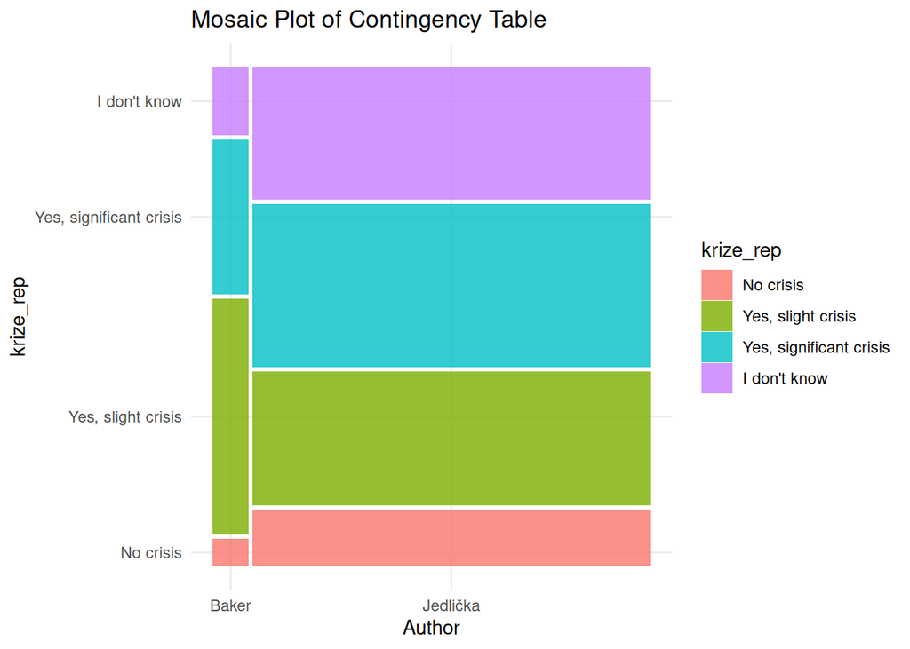

```r
# Ensure the dataframe is ungrouped
reduced_dfs_ac <- dfsknowingcontinent %>%
  filter(Subcontinent == "East Europe") %>%
  select(Author, krize_rep, n) %>%
  ungroup() %>%  # REMOVE GROUPING
  mutate(
    Author = as.character(Author),     # Convert factors to characters
    krize_rep = factor(krize_rep, levels = kr_levels)
  )


# Convert to contingency table
data_for_chisq_ac <- xtabs(n ~ Author + krize_rep, data = reduced_dfs_ac)

# Perform Chi-Square Test
chi_result <- chisq.test(data_for_chisq_ac)


# Convert contingency table to a data frame
data_df <- as.data.frame(as.table(data_for_chisq_ac))

# Create the mosaic plot
ggplot(data_df) +
  geom_mosaic(aes(weight = Freq, x = product(Author), fill = krize_rep)) +
  labs(title = "Mosaic Plot of Contingency Table",
       x = "Author",
       y = "krize_rep",
       fill = "krize_rep") +
  theme_minimal()
```

```r
# Print results
print(chi_result)
```

```
##
##  Pearson's Chi-squared test
##
## data:  data_for_chisq_ac
## X-squared = 16.647, df = 3, p-value = 0.0008351
```

…tak furt nic. Co specializace

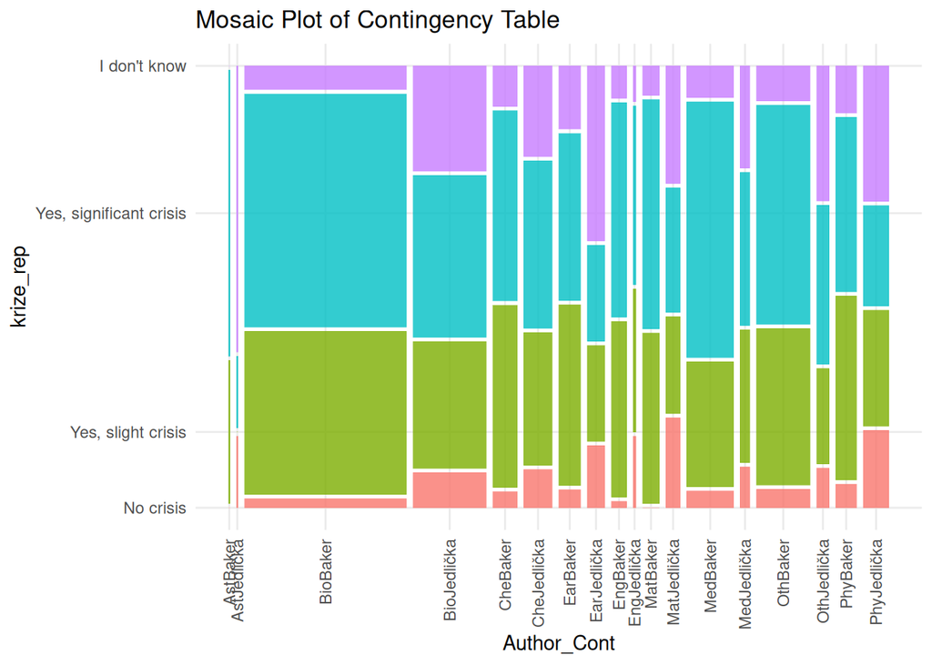

```r
dfsknowingcspec <- df %>%
#  filter(krize_rep != "I don't know") %>%
  select(krize_rep, Author, spec_hlavni) %>%
  filter(!is.na(krize_rep)) %>%
  group_by(Author, spec_hlavni) %>%
  mutate(N = n()) %>%
  group_by(Author, spec_hlavni, krize_rep, N) %>%
  summarise(n = n(), .groups = "drop") %>%
  mutate(f = round(n / N * 100, 1)) %>%
  mutate(se = sqrt((f * (100 - f)) / N),  # Standard error
         lower = f - 1.96 * se,           # 95% CI Lower Bound
         upper = f + 1.96 * se)  %>%
  mutate(Author_Spec = paste0(substr(spec_hlavni,1,3),Author))

reduced_dfs <- dfsknowingcspec %>%
  select(Author_Spec, krize_rep, n) %>%
  ungroup() %>%  # REMOVE GROUPING
  mutate(
    Author_Spec = as.character(Author_Spec),     # Convert factors to characters
       krize_rep = factor(krize_rep, levels = kr_levels)
 )


# Convert to contingency table
data_for_chisq <- xtabs(n ~ Author_Spec + krize_rep, data = reduced_dfs)

data_df <- as.data.frame(as.table(data_for_chisq))

# Create the mosaic plot
ggplot(data_df) +
  geom_mosaic(aes(weight = Freq, x = product(Author_Spec), fill = krize_rep)) +
  labs(title = "Mosaic Plot of Contingency Table",
       x = "Author_Cont",
       y = "krize_rep",
       fill = "krize_rep") +
  theme_minimal() +
  theme(
    axis.text.x = element_text(angle = 90, hjust = 1, vjust = 0.5),  # Rotate X labels
    legend.position = "none"  # Remove legend
  )
```

Tak tím to taky nebude.

## HOW MUCH PUBLISHED WORK IN YOUR FIELD IS REPRODUCIBLE?

TBD - předělat graf

Ještě jsem neudělal graf a už tuším problém :( Nikde jsem nenašel dokumentaci, jak Baker rekódovala specializace. V datech je 9 kategorií (nemá matematiku jako my). Abych se s tím nedrbal donekonečna, tak jsem to zatím uděl podle těch 9/10 kategorií, co jsou v datech, pak se když tak poradíme, jak to sloučit.

```r
dfs = df %>% select(rep_podil, spec_hlavni, Author) %>% filter(!is.na(rep_podil)) %>%
  group_by(Author, spec_hlavni) %>%
  mutate(N = n()) %>%
  group_by(Author, rep_podil, spec_hlavni, N) %>% summarise(n = n()) %>%
  mutate(f = round(n / N * 100, 1), rep_podil = factor(rep_podil))
```

[output not shown]

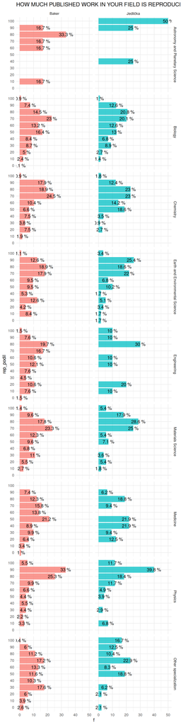

```r
ggplot(dfs, aes(y = rep_podil, x = f, fill = Author, label = paste(f, "%"))) +
  facet_grid(cols = vars(Author), rows = vars(spec_hlavni)) +
  geom_col(alpha = 0.75) +
  geom_text() +
  labs(title = "HOW MUCH PUBLISHED WORK IN YOUR FIELD IS REPRODUCIBLE?",
       # caption = paste0("Počty platných pozorování: N_Baker = ", dfs[1, "N"],
       #                  ", N_Jedlička = ", dfs[8, "N"])
       ) +
  # scale_x_log10() +
  guides(fill = "none") +
  theme_minimal()
```

## HOW MUCH PUBLISHED WORK IN YOUR FIELD IS REPRODUCIBLE? (Averages and error bars)

Tak, souhlasím, že vizualizace dle Baker hrozně tříští informaci. Proto zkusíme reprezentovat jen průměry a intervaly spolehlivosti pro tyto průměry.

```r
dfs = df %>% select(rep_podil, spec_hlavni, Author) %>% filter(!is.na(rep_podil)) %>%
  group_by(Author, spec_hlavni) %>%
  summarise(mean = mean(rep_podil, na.rm = T), sd = sd(rep_podil, na.rm = T), n = n() - 1,
            se = 1.96 * sd / (n ^ 0.5), l = paste0(round(mean, 0))) %>%
  ungroup() %>%
  mutate(spec_hlavni = fct_reorder(.f = spec_hlavni, .x = (mean * (Author == "Baker"))))
```

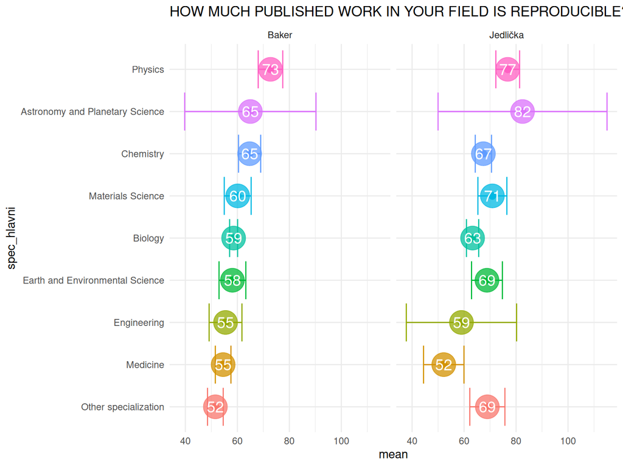

```r
ggplot(dfs, aes(y = spec_hlavni, col = spec_hlavni, x = mean,
                xmin = mean - se, xmax = mean + se, label = l)) +
  facet_grid(cols = vars(Author)) +
  geom_pointrange() +
  geom_errorbarh() +
  guides(color = "none") +
  geom_point(alpha = 0.75, size = 10) +
  geom_text(col = "white", size = 5) +
  labs(title = "HOW MUCH PUBLISHED WORK IN YOUR FIELD IS REPRODUCIBLE?",
       # caption = paste0("Počty platných pozorování: N_Baker = ", dfs[1, "N"],
       #                  ", N_Jedlička = ", dfs[8, "N"])
       ) +
  # scale_x_log10() +
  guides(fill = "none") +
  theme_minimal()
```

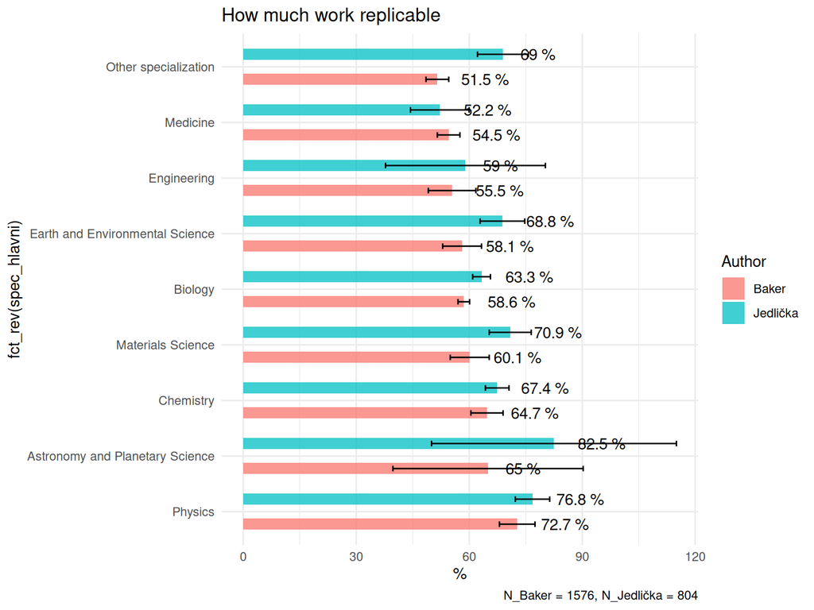

```r
dodge_width <- 0.9  # Adjust dodging width for correct spacing

ggplot(dfs, aes(y = fct_rev(spec_hlavni), x = mean, fill = Author, label = paste(round(mean,1), "%"))) +
  geom_col(alpha = 0.75, na.rm = TRUE, position = position_dodge(width = dodge_width),
           width = 0.4) +  # Reduce bar width to avoid overlap
  geom_errorbar(aes(xmin = mean-se, xmax = mean+se),
                width = 0.2,
                position = position_dodge(width = dodge_width)) +
  geom_text(position = position_dodge(width = dodge_width), hjust = -0.5) +
  labs(title = "How much work replicable", x = "%",
       caption = paste0("N_Baker = ", df_total[1, "N"],
                        ", N_Jedlička = ", df_total[8, "N"])) +
  theme_minimal()
```

## Srovnání zastoupení oborů v obou vzorcích

```r
dfs = df %>% select(spec_hlavni, Author) %>% filter(!is.na(spec_hlavni)) %>%
  group_by(Author) %>%
  mutate(N = n()) %>%
  group_by(Author, spec_hlavni, N) %>% summarise(n = n()) %>%
  mutate(f = round(n / N * 100, 1))
```

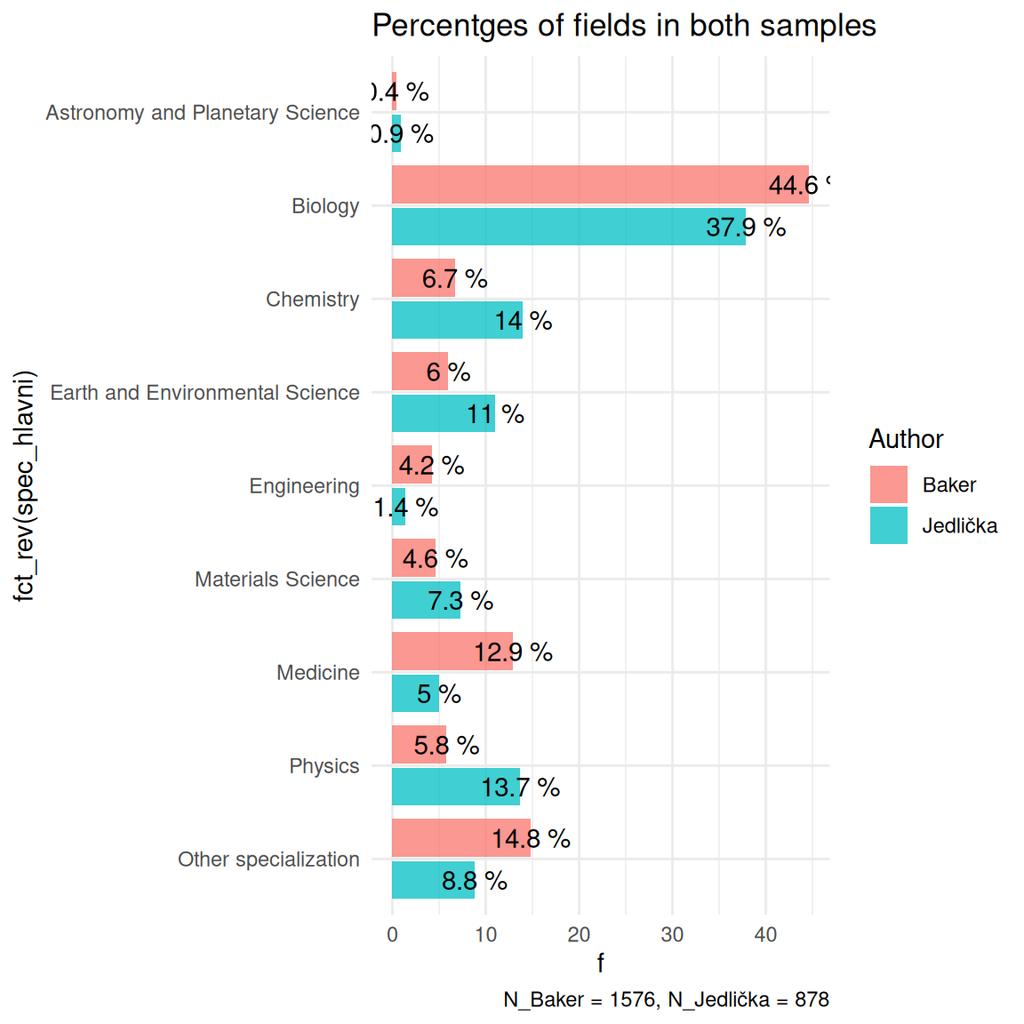

```r
ggplot(dfs, aes(y = fct_rev(spec_hlavni), x = f, fill = Author, label = paste(f, "%"))) +
  geom_col(alpha = 0.75, position = position_dodge2(reverse = T)) +
  geom_text(position = position_dodge2(width = 0.9, reverse = T)) +
  labs(title = "Percentges of fields in both samples",
       caption = paste0("N_Baker = ", dfs[1, "N"],
                        ", N_Jedlička = ", dfs[18, "N"])
       ) +
  # scale_x_log10() +
  # guides(fill = "none") +
  theme_minimal()
```

## HAVE YOU FAILED TO REPRODUCE AN EXPERIMENT? (Own/Someone’s else)

```r
dfs = df %>% select(starts_with("nerep_"), Author) %>%
  filter(!is.na(nerep_jaMuj)) %>% filter(!is.na(nerep_jaCizi)) %>% filter(!is.na(nerep_oniMuj)) %>%
  pivot_longer(cols = starts_with("nerep"), names_to = "Type", names_prefix = "nerep_") %>%
  mutate(Type = recode(Type, jaCizi = "I failed to\nreproduce others", jaMuj = "I failed to\nreproduce mine",
                       oniMuj = "They failed to\nreproduce mine") %>% factor()) %>%
  group_by(Author, Type) %>%
  mutate(N = n()) %>%
  group_by(Author, Type, value, N) %>% summarise(n = n()) %>%
  mutate(f = round(n / N * 100, 1))
```

[figure not shown]

```r
ggplot(dfs, aes(y = fct_rev(value), x = f, fill = Type, label = paste(f, "%"))) +
  facet_grid(cols = vars(Author)) +
  geom_col(alpha = 0.75, position = position_dodge2(reverse = T)) +
  geom_text(position = position_dodge2(width = 0.9, reverse = T)) +
  labs(title = "HAVE YOU FAILED TO REPRODUCE AN EXPERIMENT? (Own/Someone's else)",
       caption = paste0("N_Baker = ", dfs[1, "N"],
                        ", N_Jedlička = ", dfs[18, "N"])
       ) +
  # scale_x_log10() +
  # guides(fill = "none") +
  theme_minimal()
```

```r
dfs = df %>% select(starts_with("nerep_"), Author, spec_hlavni) %>%
  filter(!is.na(nerep_jaMuj)) %>% filter(!is.na(nerep_jaCizi)) %>% filter(!is.na(nerep_oniMuj)) %>%
  pivot_longer(cols = starts_with("nerep"), names_to = "Type", names_prefix = "nerep_") %>%
  mutate(Type = recode(Type, jaCizi = "I failed to\nreproduce others", jaMuj = "I failed to\nreproduce mine",
                       oniMuj = "They failed to\nreproduce mine") %>% factor()) %>%
  group_by(Author, Type, spec_hlavni) %>%
  mutate(N = n()) %>%
  group_by(Author, Type, value, N, spec_hlavni) %>% summarise(n = n()) %>%
  mutate(f = round(n / N * 100, 1)) %>%
  filter(value == "Yes")
```

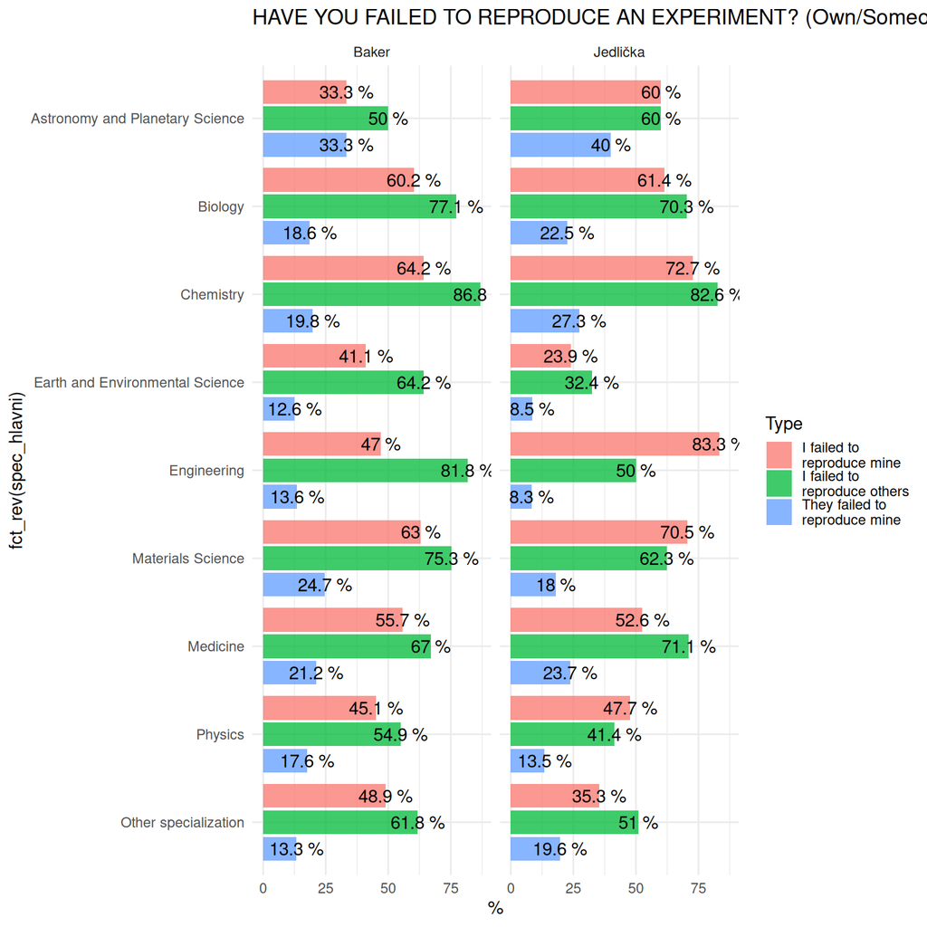

```r
ggplot(dfs, aes(y = fct_rev(spec_hlavni), x = f, fill = Type, label = paste(f, "%"))) +
  facet_grid(cols = vars(Author)) +
  geom_col(alpha = 0.75, position = position_dodge2(reverse = T)) +
  geom_text(position = position_dodge2(width = 0.9, reverse = T)) +
  labs(title = "HAVE YOU FAILED TO REPRODUCE AN EXPERIMENT? (Own/Someone's else)",
       x = "%",
       # caption = paste0("Počty platných pozorování: N_Baker = ", dfs[1, "N"],
       #                  ", N_Jedlička = ", dfs[18, "N"])
       ) +
  # scale_x_log10() +
  # guides(fill = "none") +
  theme_minimal()
```

## WHAT FACTORS CONTRIBUTE TO IRREPRODUCIBLE RESEARCH?

```r
dfs = df %>% select(starts_with("fakt_"), Author) %>%
  # filter(!is.na(nerep_jaMuj)) %>% filter(!is.na(nerep_jaCizi)) %>% filter(!is.na(nerep_oniMuj)) %>%
  pivot_longer(cols = starts_with("fakt_"), names_to = "Typ", names_prefix = "fakt_") %>%
  filter(!is.na(value)) %>% mutate(Typ = factor(Typ)) %>% group_by(Author, Typ) %>%
  mutate(N = n()) %>% filter(value != "I don't know") %>% mutate(N_bezNevim = n()) %>%
  filter(value == "Always" | value == "Very often" | value == "Sometimes") %>%
  mutate(
    value = recode(value, Always = "Always/often", `Very often` = "Always/often"),
    Typ =
      recode(
        Typ, selekc = "Selective reporting", karier = "Pressure to publish",
        statis = "Low statistical power", replik = "Not replicated enough",
        dohled = "Insuficient oversight", dokume = "Methods, code unavailable",
        design = "Poor experimental design", data = "Raw data not available",
        podvod = "Fraud", recenz = "Insufficient peer review",
        odborn = "Mistakes or inadequate expertise\nin reproduction efforts",
        metody = "Methods need particular\ntechnical expertise", variab = "Variability of reagents", smula = "Bad luck"
        )) %>%
  group_by(Author, Typ, value, N, N_bezNevim) %>% summarise(n = n()) %>%
  mutate(f = round(n / N * 100, 1),
         X = if_else(value == "Always/often" & Author == "Baker", f, 0) %>% sum(),
         f_bezNevim = round(n / N_bezNevim * 100, 1)
         ) %>% ungroup() %>% group_by(Author, Typ, N, N_bezNevim) %>%
  mutate(X = sum(X)) %>% ungroup() %>%
  mutate(Typ = fct_reorder(.f = Typ, .x = X)) %>% rename("Answer" = value)
```

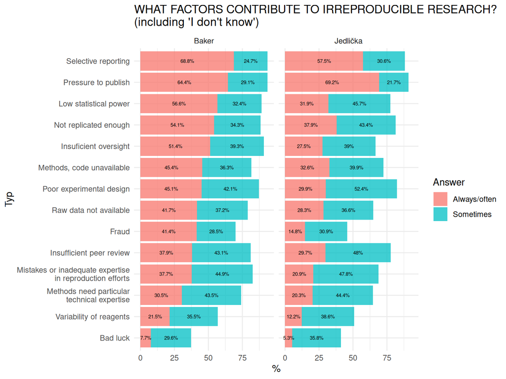

```r
ggplot(dfs, aes(y = Typ, x = f, fill = Answer, label = paste0(f, "%"))) +
  facet_grid(cols = vars(Author)) +
  geom_col(alpha = 0.75, position = position_stack(reverse = T)) +
  geom_text(position = position_stack(reverse = T, vjust = 0.5), size = 2) +
  labs(title = "WHAT FACTORS CONTRIBUTE TO IRREPRODUCIBLE RESEARCH?\n(including 'I don't know')",
       x = "%") +
  theme_minimal()
```

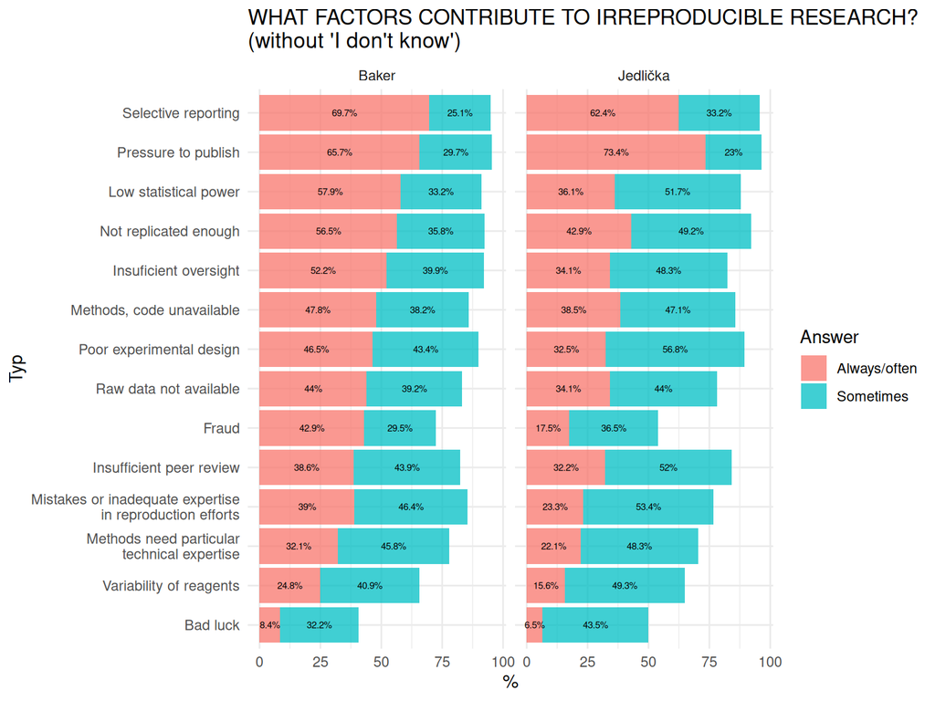

```r
ggplot(dfs, aes(y = Typ, x = f_bezNevim, fill = Answer, label = paste0(f_bezNevim, "%"))) +
  facet_grid(cols = vars(Author)) +
  geom_col(alpha = 0.75, position = position_stack(reverse = T)) +
  geom_text(position = position_stack(reverse = T, vjust = 0.5), size = 2) +
  labs(title = "WHAT FACTORS CONTRIBUTE TO IRREPRODUCIBLE RESEARCH?\n(without 'I don't know')",
       x = "%") +
  theme_minimal()
```

```r
dfs = df %>% select(starts_with("fakt_"), Author) %>%
  # filter(!is.na(nerep_jaMuj)) %>% filter(!is.na(nerep_jaCizi)) %>% filter(!is.na(nerep_oniMuj)) %>%
  pivot_longer(cols = starts_with("fakt_"), names_to = "Typ", names_prefix = "fakt_") %>%
  filter(!is.na(value)) %>% mutate(Typ = factor(Typ)) %>% group_by(Author, Typ) %>%
  mutate(N = n()) %>% filter(value != "I don't know") %>% mutate(N_bezNevim = n()) %>%
  filter(value == "Always" | value == "Very often" | value == "Sometimes") %>%
  mutate(
    Typ =
      recode(
        Typ, selekc = "Selective reporting", karier = "Pressure to publish",
        statis = "Low statistical power", replik = "Not replicated enough",
        dohled = "Insuficient oversight", dokume = "Methods, code unavailable",
        design = "Poor experimental design", data = "Raw data not available",
        podvod = "Fraud", recenz = "Insufficient peer review",
        odborn = "Mistakes or inadequate expertise\nin reproduction efforts",
        metody = "Methods need particular\ntechnical expertise", variab = "Variability of reagents", smula = "Bad luck"
        )) %>%
  group_by(Author, Typ, value, N, N_bezNevim) %>% summarise(n = n()) %>%
  mutate(f = round(n / N * 100, 1),
         X = if_else((value == "Always"  | value == "Very often") & Author == "Baker", f, 0) %>% sum(),
         f_bezNevim = round(n / N_bezNevim * 100, 1)
         ) %>% ungroup() %>% group_by(Author, Typ, N, N_bezNevim) %>%
  mutate(X = sum(X)) %>% ungroup() %>%
  mutate(Typ = fct_reorder(.f = Typ, .x = X)) %>% rename("Answer" = value)
```

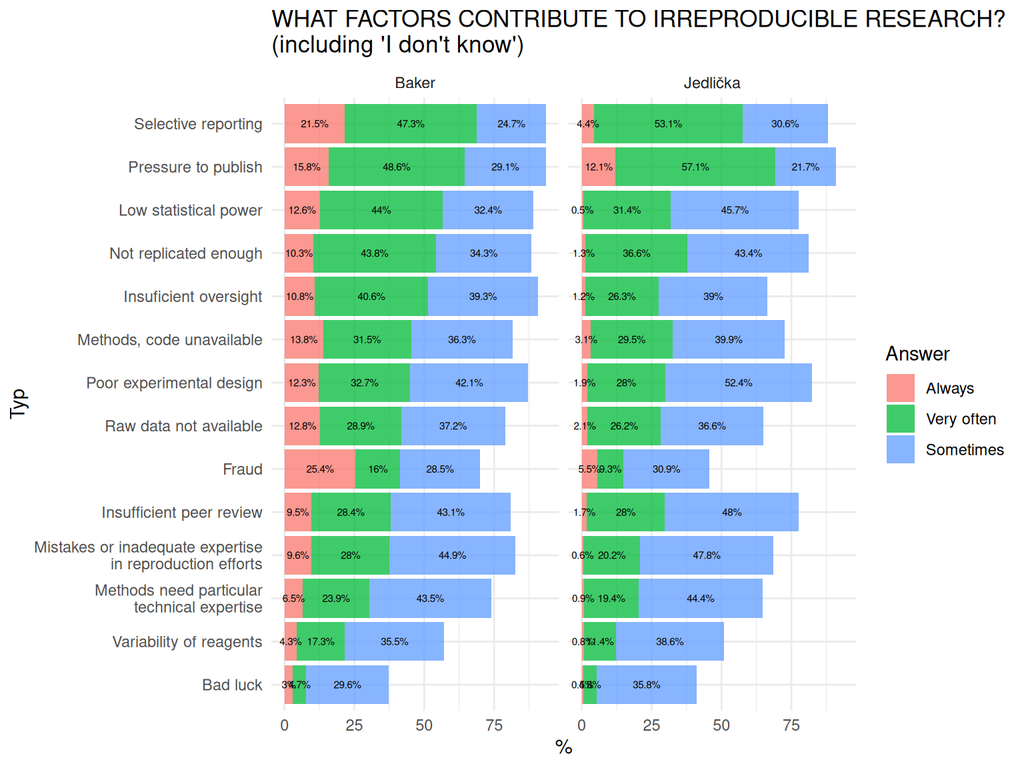

```r
ggplot(dfs, aes(y = Typ, x = f, fill = Answer, label = paste0(f, "%"))) +
  facet_grid(cols = vars(Author)) +
  geom_col(alpha = 0.75, position = position_stack(reverse = T)) +
  geom_text(position = position_stack(reverse = T, vjust = 0.5), size = 2) +
  labs(title = "WHAT FACTORS CONTRIBUTE TO IRREPRODUCIBLE RESEARCH?\n(including 'I don't know')",
       x = "%") +
  theme_minimal()
```

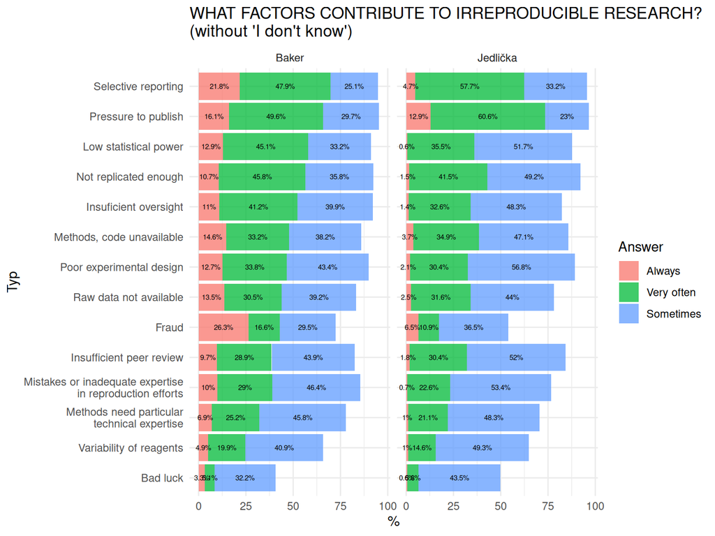

```r
ggplot(dfs, aes(y = Typ, x = f_bezNevim, fill = Answer, label = paste0(f_bezNevim, "%"))) +
  facet_grid(cols = vars(Author)) +
  geom_col(alpha = 0.75, position = position_stack(reverse = T)) +
  geom_text(position = position_stack(reverse = T, vjust = 0.5), size = 2) +
  labs(title = "WHAT FACTORS CONTRIBUTE TO IRREPRODUCIBLE RESEARCH?\n(without 'I don't know')",
       x = "%") +
  theme_minimal()
```

Tady jsem nereprodukoval graf od Baker přesně. Dal jsem si sice záležet, abych kategorie faktorů uspořádal podle součtu odpovědí v kategoriích ‘Vždy’ a ‘Velmi často’, a tak se dalo ověřit, jestli to dělám dobře a seřadím kategorie stejně. Taky kvůli tomu, abys líp našel jednotlivé faktory v těch mých zkratkách. Ale hlavně proto, abychom se mohli podívat, jak má často ona kategorii ‘Vždy’ a jak ‘Velmi často’, tedy, aby bylo jasné, v jakém poměru se ta její sdružená kategorie skládá. A tady je to zajímavé!

Přemýšlím, čím to může být? Napadá mi, že (1) Češi jsou větší idealisti, nebo (2) tím, že dotazujeme ty nejlepší instituce, tak jde o ego-defense strategy, tedy nepřiznají ani sobě, jak často se ta špína děje, nebo (3) měla Baker ve vzorku i nějaká méně prestižní pracoviště, kde se s tím prostě častěji ti vědci setkali, že se tam fixlovalo, a nebo (4) Češi chápou jinak otázku než zahraniční vědci – zatím co Čech to chápe “Když se někde najde sfixlovaný výsledek, je za tím vždy faktor X” a protože to berou tak, že k fixlování vedou různé důvody, spíš sáhnou po ‘Velmi často’ nebo ‘Někdy’ jelikož jim přijde absurdní, že za všemi fixlováními by byla kariéra, podvod atd. Naproti tomu cizinci to pochopili “Když se dostane ke slovu faktor X, jak často způsobí fixlování?” Řekl bych, že Baker určitě má na mysli ten druhý mód: jak často X vede k nekalostem. Jak bychom ověřili, že to tak chápou i Češi, resp. vyloučili, že to nepochopili jako: když se objeví nekalost, může za to X.

# „Less Scientifically Developed Culture“ effect (LSDC Effect)

## Kde je nejvíc nereprodukovatelného výzkumu?

```r
dfs = df %>%
  pivot_longer(cols = starts_with("reg_")) %>% select(Author:value) %>%
  filter(!is.na(value)) %>%
  mutate(
    value =
      recode(
        value, Asie = "Asia", Evropa = "Europe", `Severní Amerika` = "North America",
        `Ve všech regionech je podíl nereprodukovatelných studií stejný` =
          "In all regions, the proportion of\nnon-reproducible studies is the same.",
        `Nedokážu posoudit` = "I cannot tell"
      )
  ) %>% mutate(N = n(), value = factor(value) %>% fct_infreq() %>% fct_rev()) %>%
  group_by(value, N) %>% summarise(n = n()) %>% mutate(f = round(n / N * 100, 1))
```

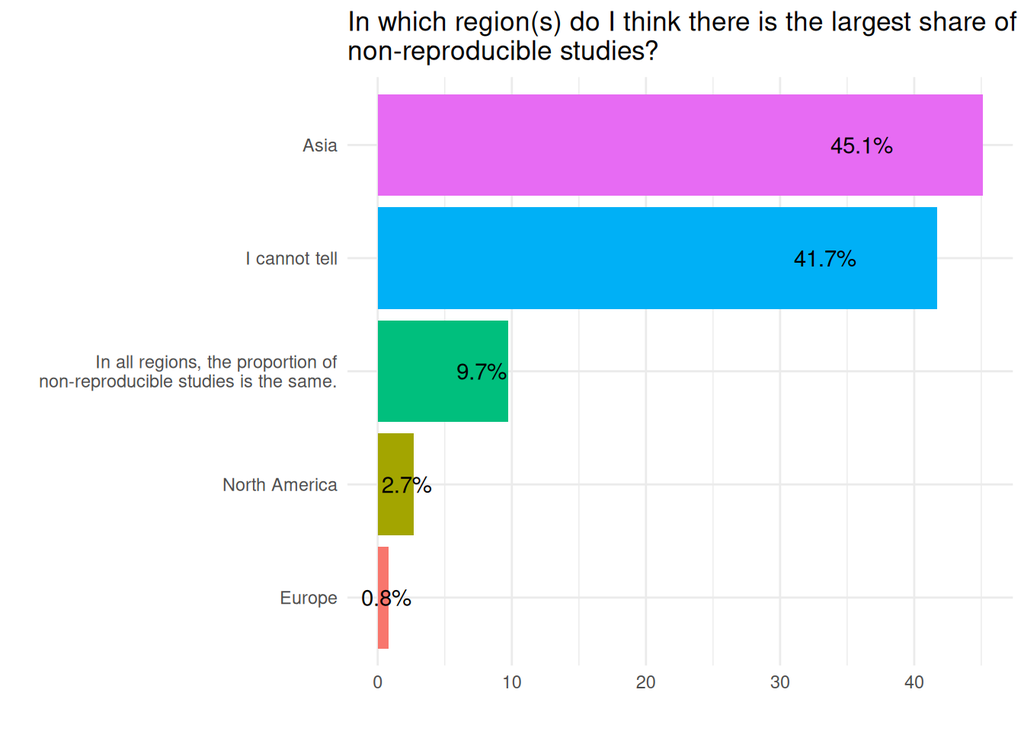

```r
ggplot(dfs, aes(y = value, x = f, fill = value, label = paste0(f, "%"))) +
  geom_col() +
  geom_text(position = position_stack(vjust = 0.8)) +
  guides(fill = "none") +
  labs(title = "In which region(s) do I think there is the largest share of\nnon-reproducible studies?",
       y = "", x = "") +
  theme_minimal()
```

## Ve které zemi nebo zemích je podle mě nejvyšší podíl nereprodukovatelného výzkumu?

```r
# Co potřebuju?
# 1) rozsekat string na jednotlivá slova a reshapovat
# 2) překódovat víceslovné názvy na jednoslovné a opravit překlepy
# 3) udělat faktor podle frekvence
msx = str_split_fixed(df$nerep_zeme, pattern = boundary("word"), n = 164) %>% as.data.frame() %>%
  rowid_to_column() %>%
  pivot_longer(cols = V1:V164) %>% filter(value != "") %>%
  mutate(
    value =
      recode(
        value,
        Afriky = "Afrika", Americe = "Amerika", amerika = "Amerika", USA = "Amerika",
        Arabské = "Arábie", Arabi = "Arábie", arabske = "Arábie", Saudi = "Arábie", Blízký = "Arábie",
        asie = "Asie", Asii = "Asie", asijských = "Asie",
        Cina = "Čína", Ćína = "Čína", Čina = "Čína", čína = "Čína", ČÍNA = "Čína", Čínská = "Čína", china  = "Čína",
        China = "Čína", Číně = "Čína", čínská = "Čína", čínských = "Čína", čínským = "Čína", CN = "Čína",
        Evropě = "Evropa",
        India = "Indie", indie = "Indie", INDIE = "Indie",
        Iran = "Írán", Irán = "Írán", Italie = "Itálie",
        Pakiskan = "Pákistán", Pakistán = "Pákistán",
        SSSR = "Rusko", ruských = "Rusko", russia = "Rusko",
        Ale = "ale", Fabulované = "fab", JV = "jv", Kde = "kde",  # Překódování slov, které nejsou země, aby zmizely.
        Mimochodem = "mmchd", Momentálně = "mmnt", Nedokážu = "nedokážu", Nejde = "nejde", Nelze = "nejde",
        Nejvíce = "nej", Neda = "ne", Nemám = "ne", Nemohu = "ne", Neřekla = "ne", Obávám = "obv", Obecně = "obc",
        Odhadovala = "odh", Podíl = "pod", Prosím = "pls", Rozvíjející = "roz", Saudská = "saud",
        Severní = "sev", Spíš = "spíš", Tam = "tam", To = "to", Toto = "to", V = "v", Velká = "vel",
        Všude = "all", Východ = "vých", Bývalé = "býv", Bývalý = "býv"
        )) %>%
  filter(str_detect(value, pattern = '[:upper:]')) %>% filter(value != "Nevím") %>%
  mutate(
    value =
      recode(
        value, Čína = "China", Indie = "India", Amerika = "USA",
        Rusko = "Russia", Írán = "Iran", Asie = "Asia", Pákistán = "Pakistan",
        Arábie = "Arabic countries", Japonsko = "Japan", Afrika = "Africa", Turecko = "Turkey"),
    U = unique(rowid) %>% length(),
    value = as_factor(value) %>% fct_infreq() %>% fct_rev(),
    N = n()) %>%
  group_by(value, N, U) %>% summarise(n = n()) %>% filter(n > 2) %>%
  mutate(f = round(n / nrow(my) * 100, 1))
```

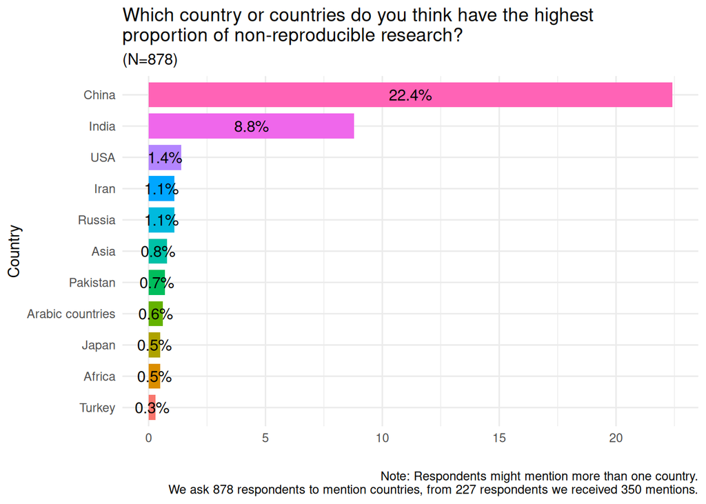

```r
  # 'nrow(my)' is size of sample,
  # 'U' is number of respondents giving at least one answer,
  # 'N' is number of mentions

ggplot(msx, aes(y = value, x = f, label = paste0(f, "%"), fill = value)) +
  geom_col(width = 0.8) +
  geom_text(position = position_stack(vjust = 0.5)) +
  guides(fill = "none") +
  labs(title = "Which country or countries do you think have the highest\nproportion of non-reproducible research?",
       y = "Country", x = "",
       caption = paste0("Note: Respondents might mention more than one country.\nWe ask ", nrow(my),
                        " respondents to mention countries, from ", msx[1, "U"], " respondents we received ",
                        msx[1, "N"], " mentions."),
       subtitle = paste0("(N=", nrow(my), ")")) +
  theme_minimal()
```

## Zaznamenal(a) jsem ze strany zahraničních vědců ve svém oboru despekt k českým vědcům nebo k české vědě (kvůli nižším standardům vědecké práce apod.)?

```r
dfs = df %>%  filter(!is.na(despekt)) %>%
  mutate(N = n()) %>% group_by(despekt, N) %>% summarise(n = n()) %>%
  mutate(f = round(n / N * 100, 1))
```

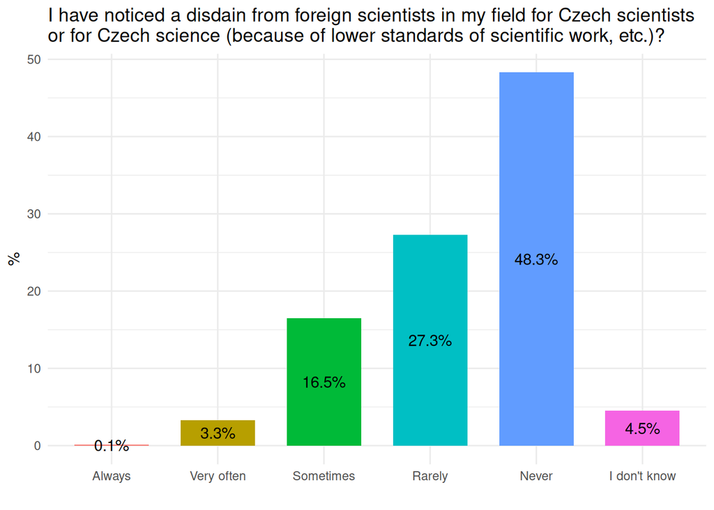

```r
ggplot(dfs, aes(x = despekt, y = f, label = paste0(f, "%"), fill = despekt)) +
  geom_col(width = 0.7) +
  geom_text(position = position_stack(vjust = 0.5)) +
  labs(title = "I have noticed a disdain from foreign scientists in my field for Czech scientists\nor for Czech science (because of lower standards of scientific work, etc.)?", x = "", y = "%") +
  guides(fill = "none") +
  theme_minimal()
```

## Pokud jsem zaznamenal(a) tento despekt:

```r
dfs = df %>% select(starts_with("desp_"), -desp_zeme) %>% rowid_to_column() %>%
  pivot_longer(cols = starts_with("desp_"), names_prefix = "desp_") %>%
  filter(!is.na(value)) %>%
  mutate(
    name =
      recode(
        name, nevim = "I cannot tell.", jazyk = "It was a linguistic issue,\nas I am not a native speaker.",
        kvalita = "It was related to the quality\nof the scientific work.", vlastni = "Other"
      ) %>% factor() %>% fct_infreq() %>% fct_rev(),
    U = unique(rowid) %>% length(), N = n()
  ) %>% group_by(U, N, name) %>% summarise(n = n()) %>%
  mutate(f = round(n / U * 100, 1))
```

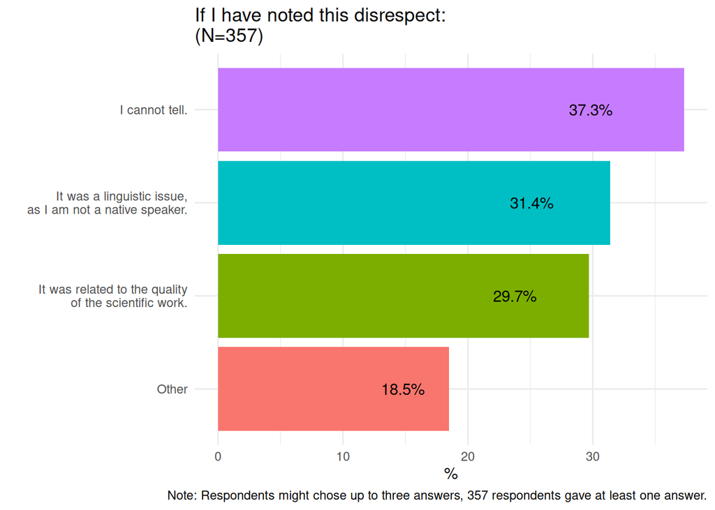

```r
ggplot(dfs, aes(y = name, x = f, fill = name, label = paste0(f, "%"))) +
  geom_col() +
  geom_text(position = position_stack(vjust = 0.8)) +
  guides(fill = "none") +
  labs(title = paste0("If I have noted this disrespect:\n(N=", dfs[1, "U"], ")"),
       caption = paste0("Note: Respondents might chose up to three answers, ", dfs[1, "U"],
                        " respondents gave at least one answer."),
       y = "", x = "%") +
  theme_minimal()
```

## Jak reaguji, když zjistím, že vědecké studie z určitých regionů vykazují ve větší míře vady nebo jsou nereprodukovatelné?

```r
dfs = df %>% select(starts_with("reakce_")) %>% rowid_to_column() %>%
  pivot_longer(cols = starts_with("reakce_"), names_prefix = "reakce_") %>%
  filter(!is.na(value)) %>%
  mutate(
    name =
      recode(
        name, nectu = "I stop reading studies\nfrom that region altogether.",
        vyberu = "I only choose labs that I believe\nare producing high quality science.",
        obezret = "I continue to read studies from this region,\nbut I am cautious about their conclusions.",
        nic = "Not at all, because even studies from this\nregion can contain valuable results.",
        stejne = "In my field, studies from all\nregions are of equal quality.",
        nevim = "I cannot tell.", vlastni = "Other"
      ) %>% factor() %>% fct_infreq() %>% fct_relevel("Other", after = 7) %>%
      fct_relevel("I cannot tell.", after = 7) %>% fct_rev(),
    U = unique(rowid) %>% length(), N = n()
  ) %>% group_by(U, N, name) %>% summarise(n = n()) %>%
  mutate(f = round(n / U * 100, 1))
```

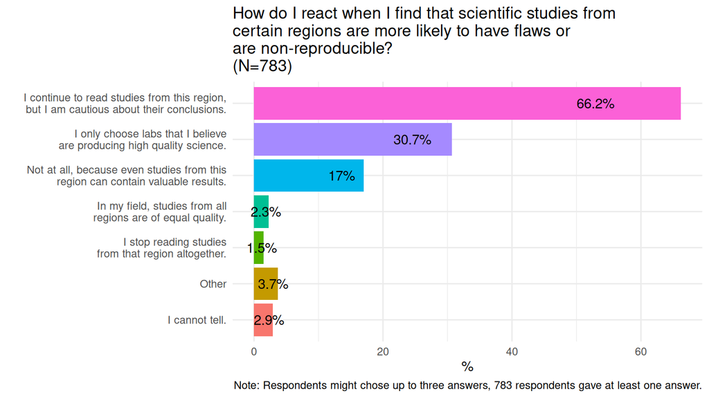

```r
ggplot(dfs, aes(y = name, x = f, fill = name, label = paste0(f, "%"))) +
  geom_col() +
  geom_text(position = position_stack(vjust = 0.8)) +
  guides(fill = "none") +
  labs(title = paste0("How do I react when I find that scientific studies from\ncertain regions are more likely to have flaws or\nare non-reproducible?\n(N=", dfs[1, "U"], ")"),
       caption = paste0("Note: Respondents might chose up to three answers, ", dfs[1, "U"],
                        " respondents gave at least one answer."),
       y = "", x = "%") +
  theme_minimal()
```

## Co poškozuje objektivitu? Jak často se to objevuje a jak velká hrozba to je?

Uděláme si na to pěkný graf! Každé položce spočítáme dva údaje:

1. Kolik procent lidí označilo položku jako hrozbu
2. Kolik je průměrná frekvence výskytu položky

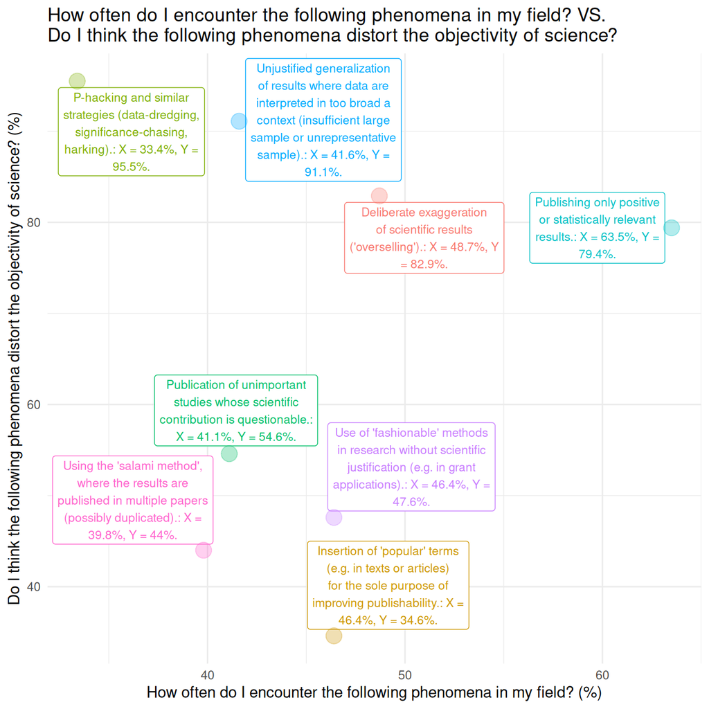

```r
dfs = df %>% select(starts_with("frek_"), starts_with("neobj_")) %>%
  pivot_longer(cols = everything()) %>% filter(!is.na(value)) %>%
  group_by(name) %>% summarise(f = round(mean(value, na.rm = T), 1)) %>%
  separate(name, sep = "_", into = c("dim", "item")) %>%
  pivot_wider(id_cols = item, names_from = dim, values_from = f) %>%
  mutate(
    item =
      recode(
        item,
        salam = "Using the 'salami method', where the results are published in multiple papers (possibly duplicated).",
        popular = "Insertion of 'popular' terms (e.g. in texts or articles) for the sole purpose of improving publishability.",
        positiv = "Publishing only positive or statistically relevant results.",
        nerepre = "Unjustified generalization of results where data are interpreted in too broad a context (insufficient large sample or unrepresentative sample).",
        hacking = "P-hacking and similar strategies (data-dredging, significance-chasing, harking).",
        zbytecne = "Publication of unimportant studies whose scientific contribution is questionable.",
        oversell = "Deliberate exaggeration of scientific results ('overselling').",
        modmet = "Use of 'fashionable' methods in research without scientific justification (e.g. in grant applications).")
  )

ggplot(dfs,
       aes(x = frek, y = neobj, col = item,
           label = str_wrap(paste0(item, ": X = ", frek, "%, Y = ", neobj, "%."), 30))) +
  geom_label_repel(size = 3) +
  geom_point(size = 5, alpha = 0.3) +
  guides(col = "none") +
  labs(title = "How often do I encounter the following phenomena in my field? VS.\nDo I think the following phenomena distort the objectivity of science?",
       y = "Do I think the following phenomena distort the objectivity of science? (%)",
       x = "How often do I encounter the following phenomena in my field? (%)") +
  theme_minimal()
```

# Demographics

## Gender:

```r
dfs = df %>%  filter(!is.na(gender)) %>%
  mutate(gender = recode(gender, Muž = "Male", Žena = "Female", Ostatní = "Other") %>%
           factor() %>% fct_infreq(),
         N = n()) %>% group_by(gender, N) %>% summarise(n = n()) %>%
  mutate(f = round(n / N * 100, 1))
```

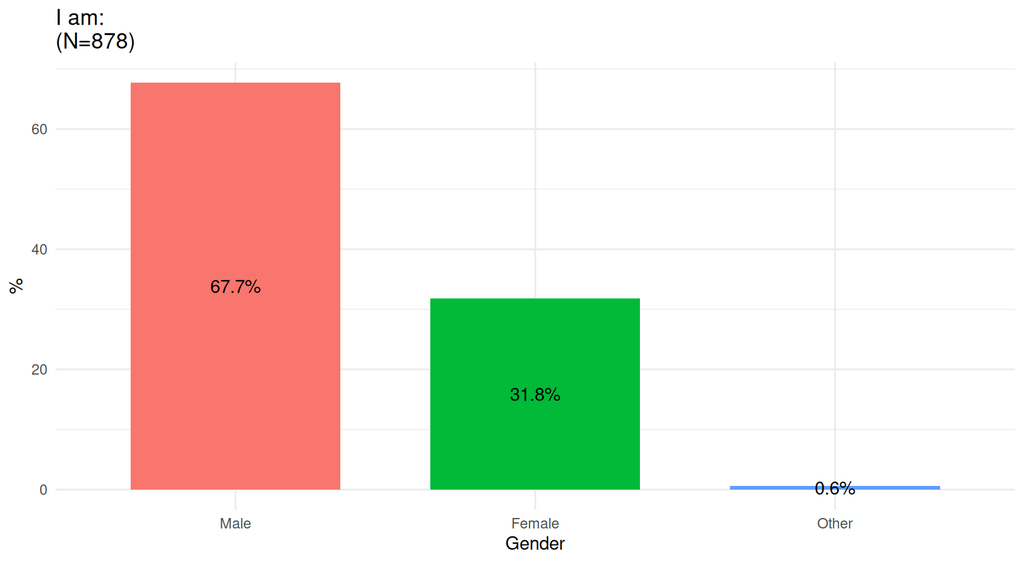

```r
ggplot(dfs, aes(x = gender, y = f, label = paste0(f, "%"), fill = gender)) +
  geom_col(width = 0.7) +
  geom_text(position = position_stack(vjust = 0.5)) +
  labs(title = paste0("I am:\n(N=", dfs$N[1],")"), x = "Gender", y = "%") +
  guides(fill = "none") +
  theme_minimal()
```

## My age is:

```r
dfs = df %>%  filter(!is.na(vek)) %>%
  mutate(vek = recode(vek, `65 a více` = "65+"),
         N = n()) %>% group_by(vek, N) %>% summarise(n = n()) %>%
  mutate(f = round(n / N * 100, 1))
```

[output not shown]

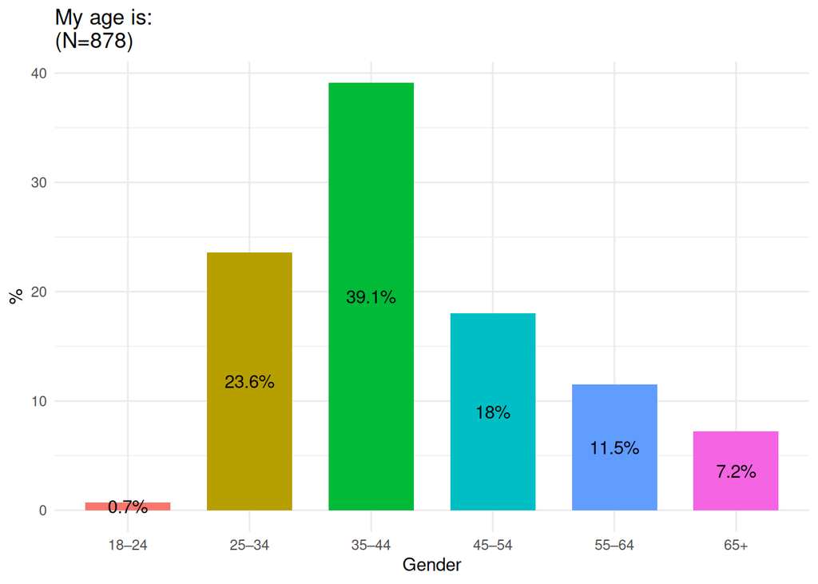

```r
ggplot(dfs, aes(x = vek, y = f, label = paste0(f, "%"), fill = vek)) +
  geom_col(width = 0.7) +
  geom_text(position = position_stack(vjust = 0.5)) +
  labs(title = paste0("My age is:\n(N=", dfs$N[1],")"), x = "Gender", y = "%") +
  guides(fill = "none") +
  theme_minimal()
```

## How many years do I work in research:

```r
dfs = df %>% filter(!is.na(kar_praxe)) %>%
  mutate(
    kar_praxe =
      recode(kar_praxe, `5–9 let` = "5–9 years", `10–19 let` = "10–19 years",
             `20 a více let` = "20+ years", `Méně než 5 let` = "<5 years") %>%
      factor(levels = c("<5 years", "5–9 years", "10–19 years", "20+ years")),
    N = n()) %>%
  group_by(kar_praxe, N) %>% summarise(n = n()) %>% mutate(f = round(n / N * 100, 1))
```

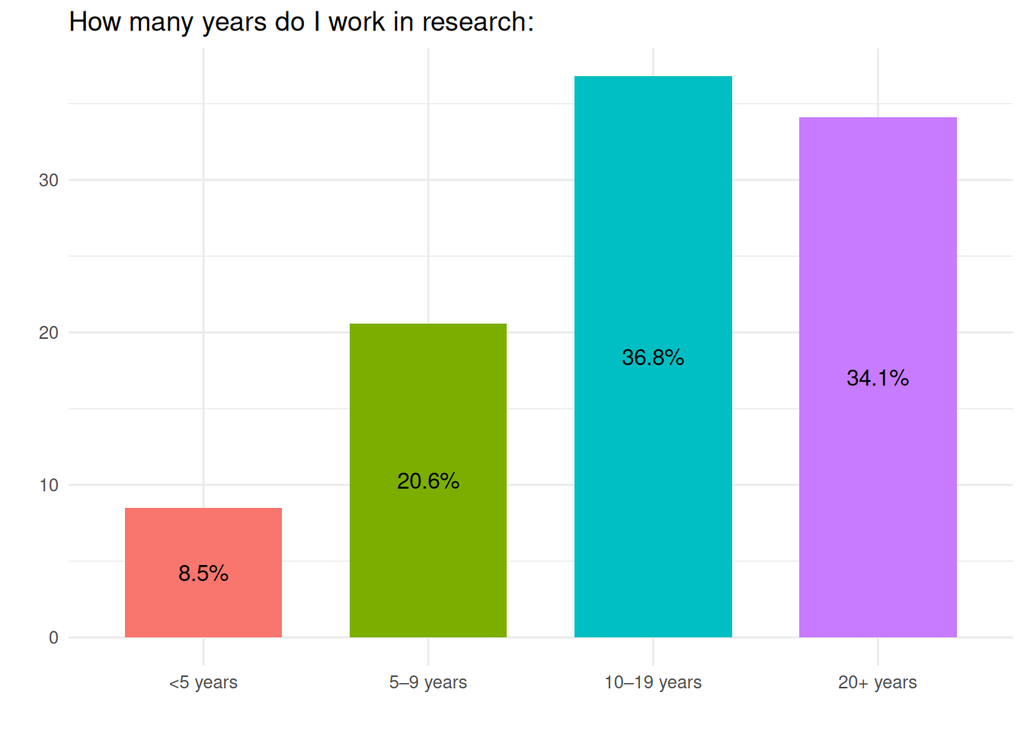

```r
ggplot(dfs, aes(x = kar_praxe, y = f, label = paste0(f, "%"), fill = kar_praxe)) +
  geom_col(width = 0.7) +
  geom_text(position = position_stack(vjust = 0.5)) +
  labs(title = "How many years do I work in research:", x = "", y = "") +
  guides(fill = "none") +
  theme_minimal()
```

## Jaká je moje nejvyšší dosažená akademická hodnost:

Má to cenu překládat? Zájímá to mimo ČR vůbec někoho?

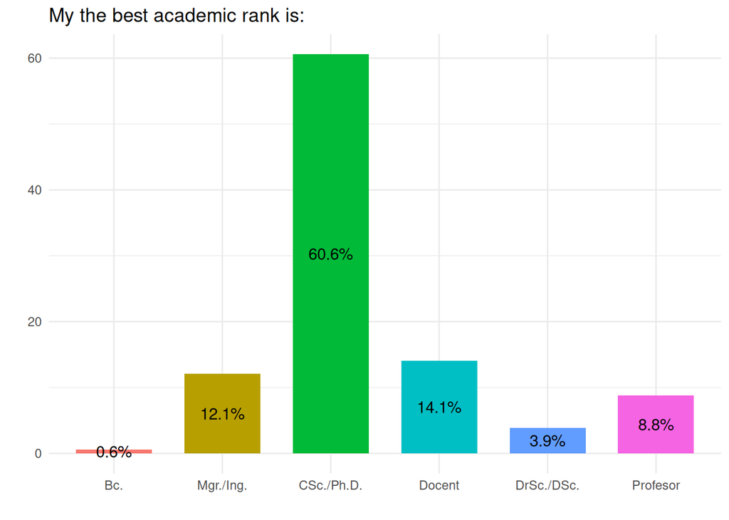

```r
df %>% filter(!is.na(kar_titul)) %>%
  mutate(
    kar_titul = fct_relevel(kar_titul, "Mgr./Ing.", after = 1),
    N = n()) %>%
  group_by(kar_titul, N) %>% summarise(n = n()) %>% mutate(f = round(n / N * 100, 1)) %>%
  ggplot(aes(x = kar_titul, y = f, label = paste0(f, "%"), fill = kar_titul)) +
  geom_col(width = 0.7) +
  geom_text(position = position_stack(vjust = 0.5)) +
  labs(title = "My the best academic rank is:", x = "", y = "") +
  guides(fill = "none") +
  theme_minimal()
```

Foo hoo! Tak jinak! Baker má data od spousty lidí, co jsou “jen” Ph.D. studenti, takže Mgr./Ing. rozhodně nechat, Baker jich má taky hafo: PhD Students má 410 (26.02%), Post-doctoral Fellows má 314 (19.92%), dohromady tyto dvě skupiny tvoří 46 % vzorku! To je taky možná důvod těch rozdílů, že těchto “relativních juniorů” je v tom jejím výzkumu mnohem víc než v tom našem.

## Počet citací (odhad):

```r
dfs = df %>% filter(!is.na(kar_citace)) %>%
  mutate(
    kar_citace =
      recode(kar_citace, `Do 100` = "0–100", `Do 500` = "101–500",
             `Do 1000` = "501–1000", `Do 5000` = "1001–5000", Více = "5000+") %>%
      factor(levels = c("0–100", "101–500", "501–1000", "1001–5000", "5000+")),
    N = n()) %>%
  group_by(kar_citace, N) %>% summarise(n = n()) %>% mutate(f = round(n / N * 100, 1))
```

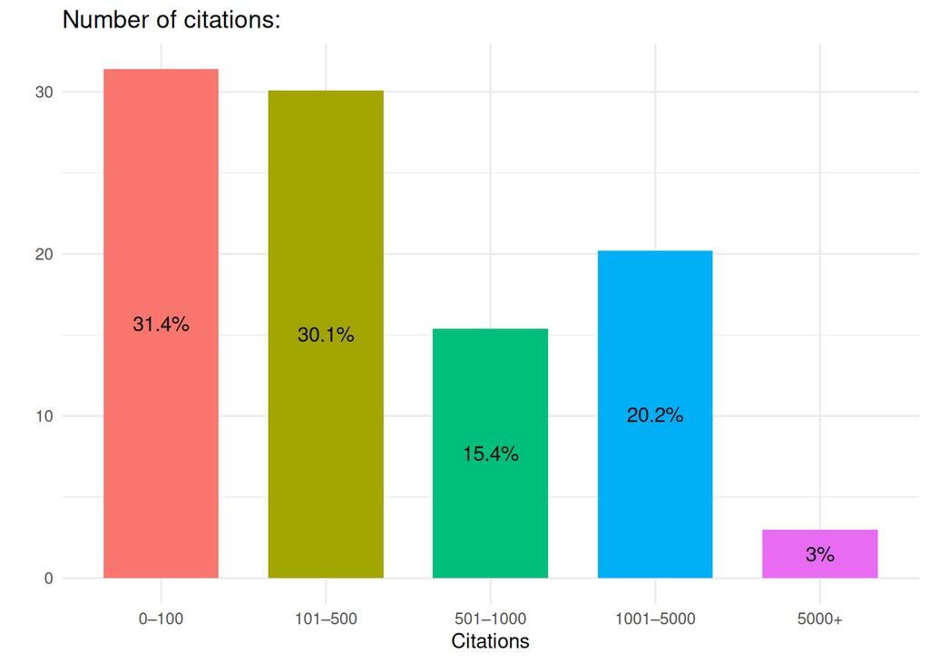

```r
ggplot(dfs, aes(x = kar_citace, y = f, label = paste0(f, "%"), fill = kar_citace)) +
  geom_col(width = 0.7) +
  geom_text(position = position_stack(vjust = 0.5)) +
  labs(title = "Number of citations:", x = "Citations", y = "") +
  guides(fill = "none") +
  theme_minimal()
```

## Publikoval jsem (i jako spoluautor) v nejlepším oborovém časopisu:

```r
dfs = df %>% filter(!is.na(kar_nejlepsi)) %>%
  mutate(
    kar_nejlepsi =
      recode(kar_nejlepsi, Ano = "Yes", Ne = "No") %>%
      factor(levels = c("Yes", "No")),
    N = n()) %>%
  group_by(kar_nejlepsi, N) %>% summarise(n = n()) %>% mutate(f = round(n / N * 100, 1))
```

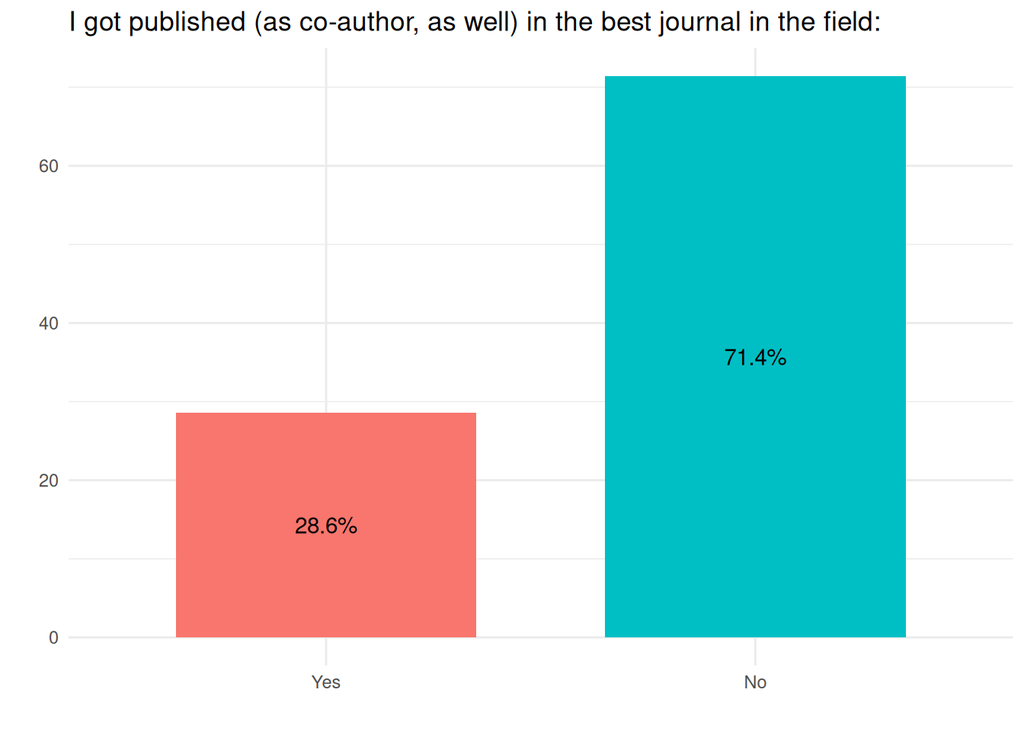

```r
ggplot(dfs, aes(x = kar_nejlepsi, y = f, label = paste0(f, "%"), fill = kar_nejlepsi)) +
  geom_col(width = 0.7) +
  geom_text(position = position_stack(vjust = 0.5)) +
  labs(title = "I got published (as co-author, as well) in the best journal in the field: ", x = "", y = "") +
  guides(fill = "none") +
  theme_minimal()
```

## Do jaké kategorie dle klasifikace Akademie věd patřím:

Asi jen pro nás, proto to zatím nepřekládám, jestli se Ti to bude na něco hodit, dej vědět. Taky tu nechávám absolutní počty. Aby to bylo použitelné, budeme to muset sjednotit napříč institucemi.

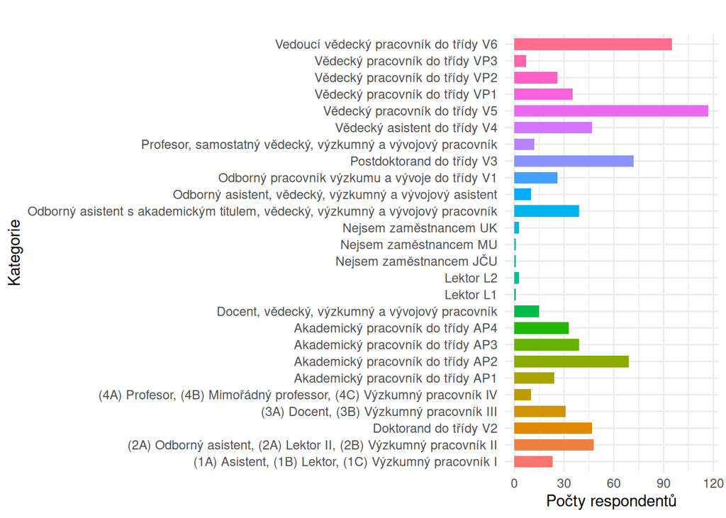

```r
df %>% filter(!is.na(kar_kategorie)) %>%
  mutate(
    kar_kategorie = fct_relevel(kar_kategorie, "Doktorand do třídy V2", after = 2)  # Pozor! Pozice této kategorie zůstane v datech stejná!
  ) %>%
  ggplot(aes(y = kar_kategorie , fill = kar_kategorie)) +
  geom_bar(width = 0.7) +
  labs(title = "", x = "Počty respondentů", y = "Kategorie") +
  guides(fill = "none") +
  theme_minimal()
```

# Dodatečný graf

```r
dfs = df %>% select(Author, starts_with("nerep_"), -c(nerep_zeme, nerep_jaMuj:nerep_jaCizi)) %>%
  pivot_longer(cols = starts_with("nerep_"), names_prefix = "nerep_") %>%
  filter(!is.na(value)) %>%
  mutate(
    name =
      recode(
        name, problem = "I think that the failure to reproduce scientific studies is a major problem in my field.",
        problemAll = "I think that the failure to reproduce scientific studies is a major problem for all fields.",
        chyba = "I think that a failure to reproduce a result most often means that the original finding is wrong.",
        valid = "I think that a failure to reproduce rarely detracts from the validity of the original finding.",
        neobj = "Irreproducible results detract from the objectivity of science.",
        veda = "Also irreproducible results are the part of the science.",
        narust = "The fraction of irreproducibile findings has increased during my carrier."
        ),
    value = factor(value, levels = c("Strongly agree", "Agree", "Neither agree nor disagree", "Disagree",
                                     "Strongly disagree", "I don't know"))
    ) %>% group_by(Author, name) %>%
  mutate(N = n()) %>% group_by(Author, name, N, value) %>%
  summarise(n = n()) %>% mutate(f = round(n / N * 100, 1))
```

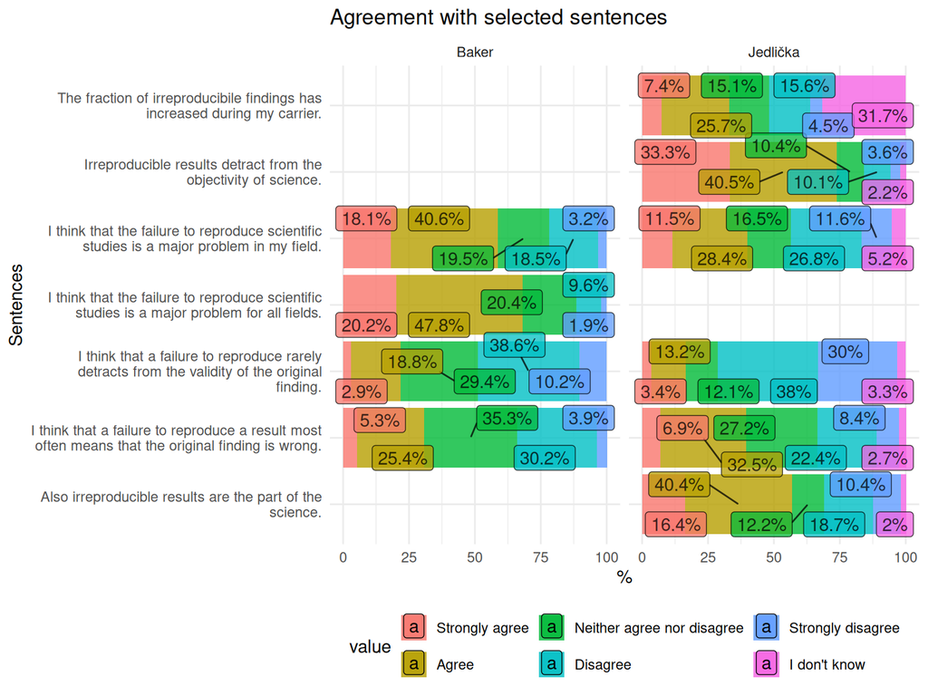

```r
dfs %>%
  ggplot(aes(y = str_wrap(name, 50), x = f, label = paste0(f, "%"), fill = value)) +
  facet_grid(cols = vars(Author)) +
  geom_col(position = position_stack(reverse = T), alpha = 0.8) +
  geom_label_repel(position = position_stack(vjust = 0.5, reverse = T), alpha = 0.75) +
  labs(y = "Sentences", x = "%", title = "Agreement with selected sentences") +
  # guides(label = "none") +
  theme_minimal() +
  theme(legend.position = "bottom")
```

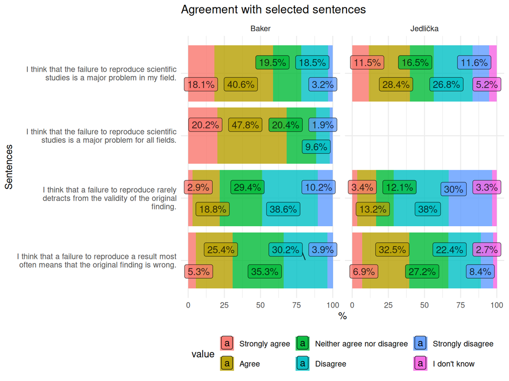

```r
dfs %>%
  filter(name == "I think that the failure to reproduce scientific studies is a major problem in my field." |
        name == "I think that the failure to reproduce scientific studies is a major problem for all fields." |
        name == "I think that a failure to reproduce a result most often means that the original finding is wrong." |
        name == "I think that a failure to reproduce rarely detracts from the validity of the original finding.") %>%
  ggplot(aes(y = str_wrap(name, 50), x = f, label = paste0(f, "%"), fill = value)) +
  facet_grid(cols = vars(Author)) +
  geom_col(position = position_stack(reverse = T), alpha = 0.8) +
  geom_label_repel(position = position_stack(vjust = 0.5, reverse = T), alpha = 0.75) +
  labs(y = "Sentences", x = "%", title = "Agreement with selected sentences") +
  # guides(label = "none") +
  theme_minimal() +
  theme(legend.position = "bottom")
```